# Elsevier 2022 SDG mapping

(AUTHKEY("alternative investment") OR AUTHKEY("alternative investments")) AND (AUTHKEY("Small scale industries") OR AUTHKEY("Small scale industry") OR AUTHKEY("Small scale enterprise") OR AUTHKEY("Small scale enterprises") OR AUTHKEY("Small industries") OR AUTHKEY("Small industry") OR AUTHKEY("Small enterprise") OR AUTHKEY("Small enterprises") OR AUTHKEY("Small entrepreneur") OR AUTHKEY("Small entrepreneurs") OR AUTHKEY("medium scale industries") OR AUTHKEY("medium scale industry") OR AUTHKEY("medium scale enterprise") OR AUTHKEY("medium scale enterprises") OR AUTHKEY("medium industries") OR AUTHKEY("medium industry") OR AUTHKEY("medium enterprise") OR AUTHKEY("medium enterprises") OR AUTHKEY("medium entrepreneur") OR AUTHKEY("medium entrepreneurs") OR AUTHKEY("microindustries") OR AUTHKEY("microindustry") OR AUTHKEY("microindustries") OR AUTHKEY("micro-industry") OR AUTHKEY("microenterprise") OR AUTHKEY("microenterprises") OR AUTHKEY("micro-enterprise") OR AUTHKEY("micro-enterprises") OR AUTHKEY("Small sized industries") OR AUTHKEY("Small sized industry") OR AUTHKEY("Small sized enterprise") OR AUTHKEY("Small sized enterprises") OR AUTHKEY("medium sized industries") OR AUTHKEY("medium sized industry") OR AUTHKEY("medium sized enterprise") OR AUTHKEY("medium sized enterprises") OR ((AUTHKEY("enterprises") OR AUTHKEY("enterprise")) AND (AUTHKEY("SMEs") OR AUTHKEY("SME"))) OR AUTHKEY("micro business") OR AUTHKEY("micro businesses") OR AUTHKEY("microbusiness") OR AUTHKEY("microbusinesses") OR AUTHKEY("micro firm") OR AUTHKEY("micro firms") OR AUTHKEY("microfirm") OR AUTHKEY("microfirms") OR AUTHKEY("small sized business") OR AUTHKEY("small sized businesses") OR AUTHKEY("small business") OR AUTHKEY("small businesses") OR AUTHKEY("small sized firm") OR AUTHKEY("small sized firms") OR AUTHKEY("small firm") OR AUTHKEY("small firms") OR AUTHKEY("medium sized business") OR AUTHKEY("medium sized businesses") OR AUTHKEY("medium business") OR AUTHKEY("medium businesses") OR AUTHKEY("medium sized firm") OR AUTHKEY("medium sized firms") OR AUTHKEY("medium firm") OR AUTHKEY("medium firms") OR AUTHKEY("manufacturing enterprises") OR AUTHKEY("manufacturing enterprise") OR AUTHKEY("manufacturing firms") OR AUTHKEY("manufacturing firm") OR AUTHKEY("manufacturing industry") OR AUTHKEY("manufacturing industries"))

)

)

OR

(

(

(TITLE-ABS("fiscal policy") OR TITLE-ABS("fiscal policies")) AND (TITLE-ABS("Small scale industries") OR TITLE-ABS("Small scale industry") OR TITLE-ABS("Small scale enterprise") OR TITLE-ABS("Small scale enterprises") OR TITLE-ABS("Small industries") OR TITLE-ABS("Small industry") OR TITLE-ABS("Small enterprise") OR TITLE-ABS("Small enterprises") OR TITLE-ABS("Small entrepreneur") OR TITLE-ABS("Small entrepreneurs") OR TITLE-ABS("medium scale industries") OR TITLE-ABS("medium scale industry") OR TITLE-ABS("medium scale enterprise") OR TITLE-ABS("medium scale enterprises") OR TITLE-ABS("medium industries") OR TITLE-ABS("medium industry") OR TITLE-ABS("medium enterprise") OR TITLE-ABS("medium enterprises") OR TITLE-ABS("medium entrepreneur") OR TITLE-ABS("medium entrepreneurs") OR TITLE-ABS("microindustries") OR TITLE-ABS("microindustry") OR TITLE-ABS("micro-industries") OR TITLE-ABS("micro-industry") OR TITLE-ABS("microenterprise") OR TITLE-ABS("microenterprises") OR TITLE-ABS("micro-enterprise") OR TITLE-ABS("micro-enterprises") OR TITLE-ABS("Small sized industries") OR TITLE-ABS("Small sized industry") OR TITLE-ABS("Small sized enterprise") OR TITLE-ABS("Small sized enterprises") OR TITLE-ABS("medium sized industries") OR TITLE-ABS("medium sized industry") OR TITLE-ABS("medium sized enterprise") OR TITLE-ABS("medium sized enterprises") OR ((TITLE-ABS("enterprises") OR TITLE-ABS("enterprise")) AND (TITLE-ABS("SMEs") OR TITLE-ABS("SME"))) OR TITLE-ABS("micro business") OR TITLE-ABS("micro businesses") OR TITLE-ABS("microbusiness") OR TITLE-ABS("microbusinesses") OR TITLE-ABS("micro firm") OR TITLE-ABS("micro firms") OR TITLE-ABS("microfirm") OR TITLE-ABS("microfirms") OR TITLE-ABS("small sized business") OR TITLE-ABS("small sized businesses") OR TITLE-ABS("small business") OR TITLE-ABS("small businesses") OR TITLE-ABS("small sized firm") OR TITLE-ABS("small sized firms") OR TITLE-ABS("small firm") OR TITLE-ABS("small firms") OR TITLE-ABS("medium sized business") OR TITLE-ABS("medium sized businesses") OR TITLE-ABS("medium business") OR TITLE-ABS("medium businesses") OR TITLE-ABS("medium sized firm") OR TITLE-ABS("medium sized firms") OR TITLE-ABS("medium firm") OR TITLE-ABS("medium firms") OR TITLE-ABS("manufacturing enterprises") OR TITLE-ABS("manufacturing enterprise") OR TITLE-ABS("manufacturing firms") OR TITLE-ABS("manufacturing firm") OR TITLE-ABS("manufacturing industry") OR TITLE-ABS("manufacturing industries"))

)

OR

(

(TITLE-ABS("fiscal policy") OR TITLE-ABS("fiscal policies")) AND (TITLE-ABS("Small scale industries") OR TITLE-ABS("Small scale industry") OR TITLE-ABS("Small scale enterprise") OR TITLE-ABS("Small scale enterprises") OR TITLE-ABS("Small industries") OR TITLE-ABS("Small industry") OR TITLE-ABS("Small enterprise") OR TITLE-ABS("Small enterprises") OR TITLE-ABS("Small entrepreneur") OR TITLE-ABS("Small entrepreneurs") OR TITLE-ABS("medium scale industries") OR TITLE-ABS("medium scale industry") OR TITLE-ABS("medium scale enterprise") OR TITLE-ABS("medium scale enterprises") OR TITLE-ABS("medium industries") OR TITLE-ABS("medium industry") OR TITLE-ABS("medium enterprise") OR TITLE-ABS("medium enterprises") OR TITLE-ABS("medium entrepreneur") OR TITLE-ABS("medium entrepreneurs") OR TITLE-ABS("microindustries") OR TITLE-ABS("microindustry") OR TITLE-ABS("microindustries") OR TITLE-ABS("micro-industry") OR TITLE-ABS("microenterprise") OR TITLE-ABS("microenterprises") OR TITLE-ABS("micro-enterprise") OR TITLE-ABS("micro-enterprises") OR TITLE-ABS("Small sized industries") OR TITLE-ABS("Small sized industry") OR TITLE-ABS("Small sized enterprise") OR TITLE-ABS("Small sized enterprises") OR TITLE-ABS("medium sized industries") OR TITLE-ABS("medium sized industry") OR TITLE-ABS("medium sized enterprise") OR TITLE-ABS("medium sized enterprises") OR ((TITLE-ABS("enterprises") OR TITLE-ABS("enterprise")) AND (TITLE-ABS("SMEs") OR TITLE-ABS("SME"))) OR TITLE-ABS("micro business") OR TITLE-ABS("micro businesses") OR TITLE-ABS("microbusiness") OR TITLE-ABS("microbusinesses") OR TITLE-ABS("micro firm") OR TITLE-ABS("micro firms") OR TITLE-ABS("microfirm") OR TITLE-ABS("microfirms") OR TITLE-ABS("small sized business") OR TITLE-ABS("small sized businesses") OR TITLE-ABS("small business") OR TITLE-ABS("small businesses") OR TITLE-ABS("small sized firm") OR TITLE-ABS("small sized firms") OR TITLE-ABS("small firm") OR TITLE-ABS("small firms") OR TITLE-ABS("medium sized business") OR TITLE-ABS("medium sized businesses") OR TITLE-ABS("medium business") OR TITLE-ABS("medium businesses") OR TITLE-ABS("medium sized firm") OR TITLE-ABS("medium sized firms") OR TITLE-ABS("medium firm") OR TITLE-ABS("medium firms") OR TITLE-ABS("manufacturing enterprises") OR TITLE-ABS("manufacturing enterprise") OR TITLE-ABS("manufacturing firms") OR TITLE-ABS("manufacturing firm") OR TITLE-ABS("manufacturing industry") OR TITLE-ABS("manufacturing industries"))

)

)

OR

(

(

(AUTHKEY("fiscal policy") OR AUTHKEY("fiscal policies")) AND (AUTHKEY("Small scale industries") OR AUTHKEY("Small scale industry") OR AUTHKEY("Small scale enterprise") OR AUTHKEY("Small scale enterprises") OR AUTHKEY("Small industries") OR AUTHKEY("Small industry") OR AUTHKEY("Small enterprise") OR AUTHKEY("Small enterprises") OR AUTHKEY("Small entrepreneur") OR AUTHKEY("Small entrepreneurs") OR AUTHKEY("medium scale industries") OR AUTHKEY("medium scale industry") OR AUTHKEY("medium scale enterprise") OR AUTHKEY("medium scale enterprises") OR AUTHKEY("medium industries") OR AUTHKEY("medium industry") OR AUTHKEY("medium enterprise") OR AUTHKEY("medium enterprises") OR AUTHKEY("medium entrepreneur") OR AUTHKEY("medium entrepreneurs") OR AUTHKEY("microindustries") OR AUTHKEY("microindustry") OR AUTHKEY("micro-industries") OR AUTHKEY("micro-industry") OR AUTHKEY("microenterprise") OR AUTHKEY("microenterprises") OR AUTHKEY("micro-enterprise") OR AUTHKEY("micro-enterprises") OR AUTHKEY("Small sized industries") OR AUTHKEY("Small sized industry") OR AUTHKEY("Small sized enterprise") OR AUTHKEY("Small sized enterprises") OR AUTHKEY("medium sized industries") OR AUTHKEY("medium sized industry") OR AUTHKEY("medium sized enterprise") OR AUTHKEY("medium sized enterprises") OR ((AUTHKEY("enterprises") OR AUTHKEY("enterprise")) AND (AUTHKEY("SMEs") OR AUTHKEY("SME"))) OR AUTHKEY("micro business") OR AUTHKEY("micro businesses") OR AUTHKEY("microbusiness") OR AUTHKEY("microbusinesses") OR AUTHKEY("micro firm") OR AUTHKEY("micro firms") OR AUTHKEY("microfirm") OR AUTHKEY("microfirms") OR AUTHKEY("small sized business") OR AUTHKEY("small sized businesses") OR AUTHKEY("small business") OR AUTHKEY("small businesses") OR AUTHKEY("small sized firm") OR AUTHKEY("small sized firms") OR AUTHKEY("small firm") OR AUTHKEY("small firms") OR AUTHKEY("medium sized business") OR AUTHKEY("medium sized businesses") OR AUTHKEY("medium business") OR AUTHKEY("medium businesses") OR AUTHKEY("medium sized firm") OR AUTHKEY("medium sized firms") OR AUTHKEY("medium firm") OR AUTHKEY("medium firms") OR AUTHKEY("manufacturing enterprises") OR AUTHKEY("manufacturing enterprise") OR AUTHKEY("manufacturing firms") OR AUTHKEY("manufacturing firm") OR AUTHKEY("manufacturing industry") OR AUTHKEY("manufacturing industries"))

)

OR

(

(AUTHKEY("fiscal policy") OR AUTHKEY("fiscal policies")) AND (AUTHKEY("Small scale industries") OR AUTHKEY("Small scale industry") OR AUTHKEY("Small scale enterprise") OR AUTHKEY("Small scale enterprises") OR AUTHKEY("Small industries") OR AUTHKEY("Small industry") OR AUTHKEY("Small enterprise") OR AUTHKEY("Small enterprises") OR AUTHKEY("Small entrepreneur") OR AUTHKEY("Small entrepreneurs") OR AUTHKEY("medium scale industries") OR AUTHKEY("medium scale industry") OR AUTHKEY("medium scale enterprise") OR AUTHKEY("medium scale enterprises") OR AUTHKEY("medium industries") OR AUTHKEY("medium industry") OR AUTHKEY("medium enterprise") OR AUTHKEY("medium enterprises") OR AUTHKEY("medium entrepreneur") OR AUTHKEY("medium entrepreneurs") OR AUTHKEY("microindustries") OR AUTHKEY("microindustry") OR AUTHKEY("microindustries") OR AUTHKEY("micro-industry") OR AUTHKEY("microenterprise") OR AUTHKEY("microenterprises") OR AUTHKEY("micro-enterprise") OR AUTHKEY("micro-enterprises") OR AUTHKEY("Small sized industries") OR AUTHKEY("Small sized industry") OR AUTHKEY("Small sized enterprise") OR AUTHKEY("Small sized enterprises") OR AUTHKEY("medium sized industries") OR AUTHKEY("medium sized industry") OR AUTHKEY("medium sized enterprise") OR AUTHKEY("medium sized enterprises") OR ((AUTHKEY("enterprises") OR AUTHKEY("enterprise")) AND (AUTHKEY("SMEs") OR AUTHKEY("SME"))) OR AUTHKEY("micro business") OR AUTHKEY("micro businesses") OR AUTHKEY("microbusiness") OR AUTHKEY("microbusinesses") OR AUTHKEY("micro firm") OR AUTHKEY("micro firms") OR AUTHKEY("microfirm") OR AUTHKEY("microfirms") OR AUTHKEY("small sized business") OR AUTHKEY("small sized businesses") OR AUTHKEY("small business") OR AUTHKEY("small businesses") OR AUTHKEY("small sized firm") OR AUTHKEY("small sized firms") OR AUTHKEY("small firm") OR AUTHKEY("small firms") OR AUTHKEY("medium sized business") OR AUTHKEY("medium sized businesses") OR AUTHKEY("medium business") OR AUTHKEY("medium businesses") OR AUTHKEY("medium sized firm") OR AUTHKEY("medium sized firms") OR AUTHKEY("medium firm") OR AUTHKEY("medium firms") OR AUTHKEY("manufacturing enterprises") OR AUTHKEY("manufacturing enterprise") OR AUTHKEY("manufacturing firms") OR AUTHKEY("manufacturing firm") OR AUTHKEY("manufacturing industry") OR AUTHKEY("manufacturing industries"))

)

)

OR TITLE-ABS

(

"SME financing"

)

OR AUTHKEY

(

"SME financing"

)

OR

(

(

(TITLE-ABS("credit") OR TITLE-ABS("credits") OR TITLE-ABS("microcredit") OR TITLE-ABS("microcredits") OR TITLE-ABS("financing") OR TITLE-ABS("financement") OR TITLE-ABS("microfinance") OR TITLE-ABS("micro-finance") OR TITLE-ABS("microfinances") OR TITLE-ABS("micro-finances") OR TITLE-ABS("financial services") OR TITLE-ABS("financial service")) AND (TITLE-ABS("Small sized industries") OR TITLE-ABS("Small sized industry") OR TITLE-ABS("Small sized enterprise") OR TITLE-ABS("Small sized enterprises") OR TITLE-ABS("medium sized industries") OR TITLE-ABS("medium sized industry") OR TITLE-ABS("medium sized enterprise") OR TITLE-ABS("medium sized enterprises") OR TITLE-ABS("enterprises SMEs") OR TITLE-ABS("enterprise SME"))

)

OR

(

(TITLE-ABS("credit") OR TITLE-ABS("credits") OR TITLE-ABS("microcredit") OR TITLE-ABS("microcredits") OR TITLE-ABS("financing") OR TITLE-ABS("financement") OR TITLE-ABS("microfinance") OR TITLE-ABS("microfinance") OR TITLE-ABS("microfinances") OR TITLE-ABS("micro-finances") OR TITLE-ABS("financial services") OR TITLE-ABS("financial service")) AND (TITLE-ABS("Small sized industries") OR TITLE-ABS("Small sized industry") OR TITLE-ABS("Small sized enterprise") OR TITLE-ABS("Small sized enterprises") OR TITLE-ABS("medium sized industries") OR TITLE-ABS("medium sized industry") OR TITLE-ABS("medium sized enterprise") OR TITLE-ABS("medium sized enterprises") OR TITLE-ABS("enterprises SMEs") OR TITLE-ABS("enterprise SME"))

)

)

OR

(

(

(AUTHKEY("credit") OR AUTHKEY("credits") OR AUTHKEY("microcredit") OR AUTHKEY("microcredits") OR AUTHKEY("financing") OR AUTHKEY("financement") OR AUTHKEY("microfinance") OR AUTHKEY("micro-finance") OR AUTHKEY("microfinances") OR AUTHKEY("micro-finances") OR AUTHKEY("financial services") OR AUTHKEY("financial service")) AND (AUTHKEY("Small sized industries") OR AUTHKEY("Small sized industry") OR AUTHKEY("Small sized enterprise") OR AUTHKEY("Small sized enterprises") OR AUTHKEY("medium sized industries") OR AUTHKEY("medium sized industry") OR AUTHKEY("medium sized enterprise") OR AUTHKEY("medium sized enterprises") OR AUTHKEY("enterprises SMEs") OR AUTHKEY("enterprise SME"))

)

OR

(

(AUTHKEY("credit") OR AUTHKEY("credits") OR AUTHKEY("microcredit") OR AUTHKEY("microcredits") OR AUTHKEY("financing") OR AUTHKEY("financement") OR AUTHKEY("microfinance") OR AUTHKEY("microfinance") OR AUTHKEY("microfinances") OR AUTHKEY("micro-finances") OR AUTHKEY("financial services") OR AUTHKEY("financial service")) AND (AUTHKEY("Small sized industries") OR AUTHKEY("Small sized industry") OR AUTHKEY("Small sized enterprise") OR AUTHKEY("Small sized enterprises") OR AUTHKEY("medium sized industries") OR AUTHKEY("medium sized industry") OR AUTHKEY("medium sized enterprise") OR AUTHKEY("medium sized enterprises") OR AUTHKEY("enterprises SMEs") OR AUTHKEY("enterprise SME"))

)

)

OR

(

(

(TITLE-ABS("commercial Investment") OR TITLE-ABS("commercial Investments")) AND (TITLE-ABS("Small scale industries") OR TITLE-ABS("Small scale industry") OR TITLE-ABS("Small scale enterprise") OR TITLE-ABS("Small scale enterprises") OR TITLE-ABS("Small industries") OR TITLE-ABS("Small industry") OR TITLE-ABS("Small enterprise") OR TITLE-ABS("Small enterprises") OR TITLE-ABS("Small entrepreneur") OR TITLE-ABS("Small entrepreneurs") OR TITLE-ABS("medium scale industries") OR TITLE-ABS("medium scale industry") OR TITLE-ABS("medium scale enterprise") OR TITLE-ABS("medium scale enterprises") OR TITLE-ABS("medium industries") OR TITLE-ABS("medium industry") OR TITLE-ABS("medium enterprise") OR TITLE-ABS("medium enterprises") OR TITLE-ABS("medium entrepreneur") OR TITLE-ABS("medium entrepreneurs") OR TITLE-ABS("microindustries") OR TITLE-ABS("microindustry") OR TITLE-ABS("micro-industries") OR TITLE-ABS("micro-industry") OR TITLE-ABS("microenterprise") OR TITLE-ABS("microenterprises") OR TITLE-ABS("micro-enterprise") OR TITLE-ABS("micro-enterprises") OR TITLE-ABS("Small sized industries") OR TITLE-ABS("Small sized industry") OR TITLE-ABS("Small sized enterprise") OR TITLE-ABS("Small sized enterprises") OR TITLE-ABS("medium sized industries") OR TITLE-ABS("medium sized industry") OR TITLE-ABS("medium sized enterprise") OR TITLE-ABS("medium sized enterprises") OR ((TITLE-ABS("enterprises") OR TITLE-ABS("enterprise")) AND (TITLE-ABS("SMEs") OR TITLE-ABS("SME"))) OR TITLE-ABS("micro business") OR TITLE-ABS("micro businesses") OR TITLE-ABS("microbusiness") OR TITLE-ABS("microbusinesses") OR TITLE-ABS("micro firm") OR TITLE-ABS("micro firms") OR TITLE-ABS("microfirm") OR TITLE-ABS("microfirms") OR TITLE-ABS("small sized business") OR TITLE-ABS("small sized businesses") OR TITLE-ABS("small business") OR TITLE-ABS("small businesses") OR TITLE-ABS("small sized firm") OR TITLE-ABS("small sized firms") OR TITLE-ABS("small firm") OR TITLE-ABS("small firms") OR TITLE-ABS("medium sized business") OR TITLE-ABS("medium sized businesses") OR TITLE-ABS("medium business") OR TITLE-ABS("medium businesses") OR TITLE-ABS("medium sized firm") OR TITLE-ABS("medium sized firms") OR TITLE-ABS("medium firm") OR TITLE-ABS("medium firms") OR TITLE-ABS("manufacturing enterprises") OR TITLE-ABS("manufacturing enterprise") OR TITLE-ABS("manufacturing firms") OR TITLE-ABS("manufacturing firm") OR TITLE-ABS("manufacturing industry") OR TITLE-ABS("manufacturing industries"))

)

OR

(

(TITLE-ABS("commercial Investment") OR TITLE-ABS("commercial Investments")) AND (TITLE-ABS("Small scale industries") OR TITLE-ABS("Small scale industry") OR TITLE-ABS("Small scale enterprise") OR TITLE-ABS("Small scale enterprises") OR TITLE-ABS("Small industries") OR TITLE-ABS("Small industry") OR TITLE-ABS("Small enterprise") OR TITLE-ABS("Small enterprises") OR TITLE-ABS("Small entrepreneur") OR TITLE-ABS("Small entrepreneurs") OR TITLE-ABS("medium scale industries") OR TITLE-ABS("medium scale industry") OR TITLE-ABS("medium scale enterprise") OR TITLE-ABS("medium scale enterprises") OR TITLE-ABS("medium industries") OR TITLE-ABS("medium industry") OR TITLE-ABS("medium enterprise") OR TITLE-ABS("medium enterprises") OR TITLE-ABS("medium entrepreneur") OR TITLE-ABS("medium entrepreneurs") OR TITLE-ABS("microindustries") OR TITLE-ABS("microindustry") OR TITLE-ABS("microindustries") OR TITLE-ABS("micro-industry") OR TITLE-ABS("microenterprise") OR TITLE-ABS("microenterprises") OR TITLE-ABS("micro-enterprise") OR TITLE-ABS("micro-enterprises") OR TITLE-ABS("Small sized industries") OR TITLE-ABS("Small sized industry") OR TITLE-ABS("Small sized enterprise") OR TITLE-ABS("Small sized enterprises") OR TITLE-ABS("medium sized industries") OR TITLE-ABS("medium sized industry") OR TITLE-ABS("medium sized enterprise") OR TITLE-ABS("medium sized enterprises") OR ((TITLE-ABS("enterprises") OR TITLE-ABS("enterprise")) AND (TITLE-ABS("SMEs") OR TITLE-ABS("SME"))) OR TITLE-ABS("micro business") OR TITLE-ABS("micro businesses") OR TITLE-ABS("microbusiness") OR TITLE-ABS("microbusinesses") OR TITLE-ABS("micro firm") OR TITLE-ABS("micro firms") OR TITLE-ABS("microfirm") OR TITLE-ABS("microfirms") OR TITLE-ABS("small sized business") OR TITLE-ABS("small sized businesses") OR TITLE-ABS("small business") OR TITLE-ABS("small businesses") OR TITLE-ABS("small sized firm") OR TITLE-ABS("small sized firms") OR TITLE-ABS("small firm") OR TITLE-ABS("small firms") OR TITLE-ABS("medium sized business") OR TITLE-ABS("medium sized businesses") OR TITLE-ABS("medium business") OR TITLE-ABS("medium businesses") OR TITLE-ABS("medium sized firm") OR TITLE-ABS("medium sized firms") OR TITLE-ABS("medium firm") OR TITLE-ABS("medium firms") OR TITLE-ABS("manufacturing enterprises") OR TITLE-ABS("manufacturing enterprise") OR TITLE-ABS("manufacturing firms") OR TITLE-ABS("manufacturing firm") OR TITLE-ABS("manufacturing industry") OR TITLE-ABS("manufacturing industries"))

)

)

OR

(

(

(AUTHKEY("commercial Investment") OR AUTHKEY("commercial Investments")) AND (AUTHKEY("Small scale industries") OR AUTHKEY("Small scale industry") OR AUTHKEY("Small scale enterprise") OR AUTHKEY("Small scale enterprises") OR AUTHKEY("Small industries") OR AUTHKEY("Small industry") OR AUTHKEY("Small enterprise") OR AUTHKEY("Small enterprises") OR AUTHKEY("Small entrepreneur") OR AUTHKEY("Small entrepreneurs") OR AUTHKEY("medium scale industries") OR AUTHKEY("medium scale industry") OR AUTHKEY("medium scale enterprise") OR AUTHKEY("medium scale enterprises") OR AUTHKEY("medium industries") OR AUTHKEY("medium industry") OR AUTHKEY("medium enterprise") OR AUTHKEY("medium enterprises") OR AUTHKEY("medium entrepreneur") OR AUTHKEY("medium entrepreneurs") OR AUTHKEY("microindustries") OR AUTHKEY("microindustry") OR AUTHKEY("micro-industries") OR AUTHKEY("micro-industry") OR AUTHKEY("microenterprise") OR AUTHKEY("microenterprises") OR AUTHKEY("micro-enterprise") OR AUTHKEY("micro-enterprises") OR AUTHKEY("Small sized industries") OR AUTHKEY("Small sized industry") OR AUTHKEY("Small sized enterprise") OR AUTHKEY("Small sized enterprises") OR AUTHKEY("medium sized industries") OR AUTHKEY("medium sized industry") OR AUTHKEY("medium sized enterprise") OR AUTHKEY("medium sized enterprises") OR ((AUTHKEY("enterprises") OR AUTHKEY("enterprise")) AND (AUTHKEY("SMEs") OR AUTHKEY("SME"))) OR AUTHKEY("micro business") OR AUTHKEY("micro businesses") OR AUTHKEY("microbusiness") OR AUTHKEY("microbusinesses") OR AUTHKEY("micro firm") OR AUTHKEY("micro firms") OR AUTHKEY("microfirm") OR AUTHKEY("microfirms") OR AUTHKEY("small sized business") OR AUTHKEY("small sized businesses") OR AUTHKEY("small business") OR AUTHKEY("small businesses") OR AUTHKEY("small sized firm") OR AUTHKEY("small sized firms") OR AUTHKEY("small firm") OR AUTHKEY("small firms") OR AUTHKEY("medium sized business") OR AUTHKEY("medium sized businesses") OR AUTHKEY("medium business") OR AUTHKEY("medium businesses") OR AUTHKEY("medium sized firm") OR AUTHKEY("medium sized firms") OR AUTHKEY("medium firm") OR AUTHKEY("medium firms") OR AUTHKEY("manufacturing enterprises") OR AUTHKEY("manufacturing enterprise") OR AUTHKEY("manufacturing firms") OR AUTHKEY("manufacturing firm") OR AUTHKEY("manufacturing industry") OR AUTHKEY("manufacturing industries"))

)

OR

(

(AUTHKEY("commercial Investment") OR AUTHKEY("commercial Investments")) AND (AUTHKEY("Small scale industries") OR AUTHKEY("Small scale industry") OR AUTHKEY("Small scale enterprise") OR AUTHKEY("Small scale enterprises") OR AUTHKEY("Small industries") OR AUTHKEY("Small industry") OR AUTHKEY("Small enterprise") OR AUTHKEY("Small enterprises") OR AUTHKEY("Small entrepreneur") OR AUTHKEY("Small entrepreneurs") OR AUTHKEY("medium scale industries") OR AUTHKEY("medium scale industry") OR AUTHKEY("medium scale enterprise") OR AUTHKEY("medium scale enterprises") OR AUTHKEY("medium industries") OR AUTHKEY("medium industry") OR AUTHKEY("medium enterprise") OR AUTHKEY("medium enterprises") OR AUTHKEY("medium entrepreneur") OR AUTHKEY("medium entrepreneurs") OR AUTHKEY("microindustries") OR AUTHKEY("microindustry") OR AUTHKEY("microindustries") OR AUTHKEY("micro-industry") OR AUTHKEY("microenterprise") OR AUTHKEY("microenterprises") OR AUTHKEY("micro-enterprise") OR AUTHKEY("micro-enterprises") OR AUTHKEY("Small sized industries") OR AUTHKEY("Small sized industry") OR AUTHKEY("Small sized enterprise") OR AUTHKEY("Small sized enterprises") OR AUTHKEY("medium sized industries") OR AUTHKEY("medium sized industry") OR AUTHKEY("medium sized enterprise") OR AUTHKEY("medium sized enterprises") OR ((AUTHKEY("enterprises") OR AUTHKEY("enterprise")) AND (AUTHKEY("SMEs") OR AUTHKEY("SME"))) OR AUTHKEY("micro business") OR AUTHKEY("micro businesses") OR AUTHKEY("microbusiness") OR AUTHKEY("microbusinesses") OR AUTHKEY("micro firm") OR AUTHKEY("micro firms") OR AUTHKEY("microfirm") OR AUTHKEY("microfirms") OR AUTHKEY("small sized business") OR AUTHKEY("small sized businesses") OR AUTHKEY("small business") OR AUTHKEY("small businesses") OR AUTHKEY("small sized firm") OR AUTHKEY("small sized firms") OR AUTHKEY("small firm") OR AUTHKEY("small firms") OR AUTHKEY("medium sized business") OR AUTHKEY("medium sized businesses") OR AUTHKEY("medium business") OR AUTHKEY("medium businesses") OR AUTHKEY("medium sized firm") OR AUTHKEY("medium sized firms") OR AUTHKEY("medium firm") OR AUTHKEY("medium firms") OR AUTHKEY("manufacturing enterprises") OR AUTHKEY("manufacturing enterprise") OR AUTHKEY("manufacturing firms") OR AUTHKEY("manufacturing firm") OR AUTHKEY("manufacturing industry") OR AUTHKEY("manufacturing industries"))

)

)

OR

(

(

TITLE-ABS("credit") OR TITLE-ABS("credits") OR TITLE-ABS("microcredit") OR TITLE-ABS("microcredits")

)

AND

(

TITLE-ABS("Small scale industries") OR TITLE-ABS("Small scale industry")

)

)

OR

(

(

AUTHKEY("credit") OR AUTHKEY("credits") OR AUTHKEY("microcredit") OR AUTHKEY("microcredits")

)

AND

(

AUTHKEY("Small scale industries") OR AUTHKEY("Small scale industry")

)

)

OR

(

(

(TITLE-ABS("credit") OR TITLE-ABS("credits") OR TITLE-ABS("microcredit") OR TITLE-ABS("microcredits") OR TITLE-ABS("financing") OR TITLE-ABS("financement") OR TITLE-ABS("microfinance") OR TITLE-ABS("micro-finance") OR TITLE-ABS("microfinances") OR TITLE-ABS("micro-finances") OR TITLE-ABS("financial services") OR TITLE-ABS("financial service")) AND ((TITLE-ABS("enterprises") OR TITLE-ABS("enterprise")) AND (TITLE-ABS("SMEs") OR TITLE-ABS("SME")))

)

OR

(

(TITLE-ABS("credit") OR TITLE-ABS("credits") OR TITLE-ABS("microcredit") OR TITLE-ABS("microcredits") OR TITLE-ABS("financing") OR TITLE-ABS("financement") OR TITLE-ABS("microfinance") OR TITLE-ABS("microfinance") OR TITLE-ABS("microfinances") OR TITLE-ABS("micro-finances") OR TITLE-ABS("financial services") OR TITLE-ABS("financial service")) AND ((TITLE-ABS("enterprises") OR TITLE-ABS("enterprise")) AND (TITLE-ABS("SMEs") OR TITLE-ABS("SME")))

)

)

OR

(

(

(AUTHKEY("credit") OR AUTHKEY("credits") OR AUTHKEY("microcredit") OR AUTHKEY("microcredits") OR AUTHKEY("financing") OR AUTHKEY("financement") OR AUTHKEY("microfinance") OR AUTHKEY("micro-finance") OR AUTHKEY("microfinances") OR AUTHKEY("micro-finances") OR AUTHKEY("financial services") OR AUTHKEY("financial service")) AND ((AUTHKEY("enterprises") OR AUTHKEY("enterprise")) AND (AUTHKEY("SMEs") OR AUTHKEY("SME")))

)

OR

(

(AUTHKEY("credit") OR AUTHKEY("credits") OR AUTHKEY("microcredit") OR AUTHKEY("microcredits") OR AUTHKEY("financing") OR AUTHKEY("financement") OR AUTHKEY("microfinance") OR AUTHKEY("microfinance") OR AUTHKEY("microfinances") OR AUTHKEY("micro-finances") OR AUTHKEY("financial services") OR AUTHKEY("financial service")) AND ((AUTHKEY("enterprises") OR AUTHKEY("enterprise")) AND (AUTHKEY("SMEs") OR AUTHKEY("SME")))

)

)

OR

(

(

(TITLE-ABS("financing") OR TITLE-ABS("financement") OR TITLE-ABS("microfinance") OR TITLE-ABS("micro-finance") OR TITLE-ABS("microfinances") OR TITLE-ABS("micro-finances")) AND (TITLE-ABS("Small scale industries") OR TITLE-ABS("Small scale industry") OR TITLE-ABS("Small scale enterprise") OR TITLE-ABS("Small scale enterprises") OR TITLE-ABS("Small industries") OR TITLE-ABS("Small industry") OR TITLE-ABS("Small enterprise") OR TITLE-ABS("Small enterprises") OR TITLE-ABS("Small entrepreneur") OR TITLE-ABS("Small entrepreneurs"))

)

OR

(

(TITLE-ABS("financing") OR TITLE-ABS("financement") OR TITLE-ABS("microfinance") OR TITLE-ABS("microfinance") OR TITLE-ABS("microfinances") OR TITLE-ABS("micro-finances")) AND (TITLE-ABS("Small scale industries") OR TITLE-ABS("Small scale industry") OR TITLE-ABS("Small scale enterprise") OR TITLE-ABS("Small scale enterprises") OR TITLE-ABS("Small industries") OR TITLE-ABS("Small industry") OR TITLE-ABS("Small enterprise") OR TITLE-ABS("Small enterprises") OR TITLE-ABS("Small entrepreneur") OR TITLE-ABS("Small entrepreneurs"))

)

)

OR

(

(

(AUTHKEY("financing") OR AUTHKEY("financement") OR AUTHKEY("microfinance") OR AUTHKEY("micro-finance") OR AUTHKEY("microfinances") OR AUTHKEY("micro-finances")) AND (AUTHKEY("Small scale industries") OR AUTHKEY("Small scale industry") OR AUTHKEY("Small scale enterprise") OR AUTHKEY("Small scale enterprises") OR AUTHKEY("Small industries") OR AUTHKEY("Small industry") OR AUTHKEY("Small enterprise") OR AUTHKEY("Small enterprises") OR AUTHKEY("Small entrepreneur") OR AUTHKEY("Small entrepreneurs"))

)

OR

(

(AUTHKEY("financing") OR AUTHKEY("financement") OR AUTHKEY("microfinance") OR AUTHKEY("microfinance") OR AUTHKEY("microfinances") OR AUTHKEY("micro-finances")) AND (AUTHKEY("Small scale industries") OR AUTHKEY("Small scale industry") OR AUTHKEY("Small scale enterprise") OR AUTHKEY("Small scale enterprises") OR AUTHKEY("Small industries") OR AUTHKEY("Small industry") OR AUTHKEY("Small enterprise") OR AUTHKEY("Small enterprises") OR AUTHKEY("Small entrepreneur") OR AUTHKEY("Small entrepreneurs"))

)

)

OR

(

TITLE-ABS

(

"business angel"

)

OR TITLE-ABS

(

"business angels"

)

)

OR

(

AUTHKEY

(

"business angel"

)

OR AUTHKEY

(

"business angels"

)

)

OR

(

(

(TITLE-ABS("capital Investment") OR TITLE-ABS("capital Investments") OR TITLE-ABS("investing capital") OR TITLE-ABS("investing capitals")) AND (TITLE-ABS("Small scale industries") OR TITLE-ABS("Small scale industry") OR TITLE-ABS("Small scale enterprise") OR TITLE-ABS("Small scale enterprises") OR TITLE-ABS("Small industries") OR TITLE-ABS("Small industry") OR TITLE-ABS("Small enterprise") OR TITLE-ABS("Small enterprises") OR TITLE-ABS("Small entrepreneur") OR TITLE-ABS("Small entrepreneurs") OR TITLE-ABS("medium scale industries") OR TITLE-ABS("medium scale industry") OR TITLE-ABS("medium scale enterprise") OR TITLE-ABS("medium scale enterprises") OR TITLE-ABS("medium industries") OR TITLE-ABS("medium industry") OR TITLE-ABS("medium enterprise") OR TITLE-ABS("medium enterprises") OR TITLE-ABS("medium entrepreneur") OR TITLE-ABS("medium entrepreneurs") OR TITLE-ABS("microindustries") OR TITLE-ABS("microindustry") OR TITLE-ABS("micro-industries") OR TITLE-ABS("micro-industry") OR TITLE-ABS("microenterprise") OR TITLE-ABS("microenterprises") OR TITLE-ABS("micro-enterprise") OR TITLE-ABS("micro-enterprises") OR TITLE-ABS("Small sized industries") OR TITLE-ABS("Small sized industry") OR TITLE-ABS("Small sized enterprise") OR TITLE-ABS("Small sized enterprises") OR TITLE-ABS("medium sized industries") OR TITLE-ABS("medium sized industry") OR TITLE-ABS("medium sized enterprise") OR TITLE-ABS("medium sized enterprises") OR ((TITLE-ABS("enterprises") OR TITLE-ABS("enterprise")) AND (TITLE-ABS("SMEs") OR TITLE-ABS("SME"))) OR TITLE-ABS("micro business") OR TITLE-ABS("micro businesses") OR TITLE-ABS("microbusiness") OR TITLE-ABS("microbusinesses") OR TITLE-ABS("micro firm") OR TITLE-ABS("micro firms") OR TITLE-ABS("microfirm") OR TITLE-ABS("microfirms") OR TITLE-ABS("small sized business") OR TITLE-ABS("small sized businesses") OR TITLE-ABS("small business") OR TITLE-ABS("small businesses") OR TITLE-ABS("small sized firm") OR TITLE-ABS("small sized firms") OR TITLE-ABS("small firm") OR TITLE-ABS("small firms") OR TITLE-ABS("medium sized business") OR TITLE-ABS("medium sized businesses") OR TITLE-ABS("medium business") OR TITLE-ABS("medium businesses") OR TITLE-ABS("medium sized firm") OR TITLE-ABS("medium sized firms") OR TITLE-ABS("medium firm") OR TITLE-ABS("medium firms") OR TITLE-ABS("manufacturing enterprises") OR TITLE-ABS("manufacturing enterprise") OR TITLE-ABS("manufacturing firms") OR TITLE-ABS("manufacturing firm") OR TITLE-ABS("manufacturing industry") OR TITLE-ABS("manufacturing industries"))

)

OR

(

(TITLE-ABS("capital Investment") OR TITLE-ABS("capital Investments") OR TITLE-ABS("investing capital") OR TITLE-ABS("investing capitals")) AND (TITLE-ABS("Small scale industries") OR TITLE-ABS("Small scale industry") OR TITLE-ABS("Small scale enterprise") OR TITLE-ABS("Small scale enterprises") OR TITLE-ABS("Small industries") OR TITLE-ABS("Small industry") OR TITLE-ABS("Small enterprise") OR TITLE-ABS("Small enterprises") OR TITLE-ABS("Small entrepreneur") OR TITLE-ABS("Small entrepreneurs") OR TITLE-ABS("medium scale industries") OR TITLE-ABS("medium scale industry") OR TITLE-ABS("medium scale enterprise") OR TITLE-ABS("medium scale enterprises") OR TITLE-ABS("medium industries") OR TITLE-ABS("medium industry") OR TITLE-ABS("medium enterprise") OR TITLE-ABS("medium enterprises") OR TITLE-ABS("medium entrepreneur") OR TITLE-ABS("medium entrepreneurs") OR TITLE-ABS("microindustries") OR TITLE-ABS("microindustry") OR TITLE-ABS("microindustries") OR TITLE-ABS("micro-industry") OR TITLE-ABS("microenterprise") OR TITLE-ABS("microenterprises") OR TITLE-ABS("micro-enterprise") OR TITLE-ABS("micro-enterprises") OR TITLE-ABS("Small sized industries") OR TITLE-ABS("Small sized industry") OR TITLE-ABS("Small sized enterprise") OR TITLE-ABS("Small sized enterprises") OR TITLE-ABS("medium sized industries") OR TITLE-ABS("medium sized industry") OR TITLE-ABS("medium sized enterprise") OR TITLE-ABS("medium sized enterprises") OR ((TITLE-ABS("enterprises") OR TITLE-ABS("enterprise")) AND (TITLE-ABS("SMEs") OR TITLE-ABS("SME"))) OR TITLE-ABS("micro business") OR TITLE-ABS("micro businesses") OR TITLE-ABS("microbusiness") OR TITLE-ABS("microbusinesses") OR TITLE-ABS("micro firm") OR TITLE-ABS("micro firms") OR TITLE-ABS("microfirm") OR TITLE-ABS("microfirms") OR TITLE-ABS("small sized business") OR TITLE-ABS("small sized businesses") OR TITLE-ABS("small business") OR TITLE-ABS("small businesses") OR TITLE-ABS("small sized firm") OR TITLE-ABS("small sized firms") OR TITLE-ABS("small firm") OR TITLE-ABS("small firms") OR TITLE-ABS("medium sized business") OR TITLE-ABS("medium sized businesses") OR TITLE-ABS("medium business") OR TITLE-ABS("medium businesses") OR TITLE-ABS("medium sized firm") OR TITLE-ABS("medium sized firms") OR TITLE-ABS("medium firm") OR TITLE-ABS("medium firms") OR TITLE-ABS("manufacturing enterprises") OR TITLE-ABS("manufacturing enterprise") OR TITLE-ABS("manufacturing firms") OR TITLE-ABS("manufacturing firm") OR TITLE-ABS("manufacturing industry") OR TITLE-ABS("manufacturing industries"))

)

)

OR

(

(

(AUTHKEY("capital Investment") OR AUTHKEY("capital Investments") OR AUTHKEY("investing capital") OR AUTHKEY("investing capitals")) AND (AUTHKEY("Small scale industries") OR AUTHKEY("Small scale industry") OR AUTHKEY("Small scale enterprise") OR AUTHKEY("Small scale enterprises") OR AUTHKEY("Small industries") OR AUTHKEY("Small industry") OR AUTHKEY("Small enterprise") OR AUTHKEY("Small enterprises") OR AUTHKEY("Small entrepreneur") OR AUTHKEY("Small entrepreneurs") OR AUTHKEY("medium scale industries") OR AUTHKEY("medium scale industry") OR AUTHKEY("medium scale enterprise") OR AUTHKEY("medium scale enterprises") OR AUTHKEY("medium industries") OR AUTHKEY("medium industry") OR AUTHKEY("medium enterprise") OR AUTHKEY("medium enterprises") OR AUTHKEY("medium entrepreneur") OR AUTHKEY("medium entrepreneurs") OR AUTHKEY("microindustries") OR AUTHKEY("microindustry") OR AUTHKEY("micro-industries") OR AUTHKEY("micro-industry") OR AUTHKEY("microenterprise") OR AUTHKEY("microenterprises") OR AUTHKEY("micro-enterprise") OR AUTHKEY("micro-enterprises") OR AUTHKEY("Small sized industries") OR AUTHKEY("Small sized industry") OR AUTHKEY("Small sized enterprise") OR AUTHKEY("Small sized enterprises") OR AUTHKEY("medium sized industries") OR AUTHKEY("medium sized industry") OR AUTHKEY("medium sized enterprise") OR AUTHKEY("medium sized enterprises") OR ((AUTHKEY("enterprises") OR AUTHKEY("enterprise")) AND (AUTHKEY("SMEs") OR AUTHKEY("SME"))) OR AUTHKEY("micro business") OR AUTHKEY("micro businesses") OR AUTHKEY("microbusiness") OR AUTHKEY("microbusinesses") OR AUTHKEY("micro firm") OR AUTHKEY("micro firms") OR AUTHKEY("microfirm") OR AUTHKEY("microfirms") OR AUTHKEY("small sized business") OR AUTHKEY("small sized businesses") OR AUTHKEY("small business") OR AUTHKEY("small businesses") OR AUTHKEY("small sized firm") OR AUTHKEY("small sized firms") OR AUTHKEY("small firm") OR AUTHKEY("small firms") OR AUTHKEY("medium sized business") OR AUTHKEY("medium sized businesses") OR AUTHKEY("medium business") OR AUTHKEY("medium businesses") OR AUTHKEY("medium sized firm") OR AUTHKEY("medium sized firms") OR AUTHKEY("medium firm") OR AUTHKEY("medium firms") OR AUTHKEY("manufacturing enterprises") OR AUTHKEY("manufacturing enterprise") OR AUTHKEY("manufacturing firms") OR AUTHKEY("manufacturing firm") OR AUTHKEY("manufacturing industry") OR AUTHKEY("manufacturing industries"))

)

OR

(

(AUTHKEY("capital Investment") OR AUTHKEY("capital Investments") OR AUTHKEY("investing capital") OR AUTHKEY("investing capitals")) AND (AUTHKEY("Small scale industries") OR AUTHKEY("Small scale industry") OR AUTHKEY("Small scale enterprise") OR AUTHKEY("Small scale enterprises") OR AUTHKEY("Small industries") OR AUTHKEY("Small industry") OR AUTHKEY("Small enterprise") OR AUTHKEY("Small enterprises") OR AUTHKEY("Small entrepreneur") OR AUTHKEY("Small entrepreneurs") OR AUTHKEY("medium scale industries") OR AUTHKEY("medium scale industry") OR AUTHKEY("medium scale enterprise") OR AUTHKEY("medium scale enterprises") OR AUTHKEY("medium industries") OR AUTHKEY("medium industry") OR AUTHKEY("medium enterprise") OR AUTHKEY("medium enterprises") OR AUTHKEY("medium entrepreneur") OR AUTHKEY("medium entrepreneurs") OR AUTHKEY("microindustries") OR AUTHKEY("microindustry") OR AUTHKEY("microindustries") OR AUTHKEY("micro-industry") OR AUTHKEY("microenterprise") OR AUTHKEY("microenterprises") OR AUTHKEY("micro-enterprise") OR AUTHKEY("micro-enterprises") OR AUTHKEY("Small sized industries") OR AUTHKEY("Small sized industry") OR AUTHKEY("Small sized enterprise") OR AUTHKEY("Small sized enterprises") OR AUTHKEY("medium sized industries") OR AUTHKEY("medium sized industry") OR AUTHKEY("medium sized enterprise") OR AUTHKEY("medium sized enterprises") OR ((AUTHKEY("enterprises") OR AUTHKEY("enterprise")) AND (AUTHKEY("SMEs") OR AUTHKEY("SME"))) OR AUTHKEY("micro business") OR AUTHKEY("micro businesses") OR AUTHKEY("microbusiness") OR AUTHKEY("microbusinesses") OR AUTHKEY("micro firm") OR AUTHKEY("micro firms") OR AUTHKEY("microfirm") OR AUTHKEY("microfirms") OR AUTHKEY("small sized business") OR AUTHKEY("small sized businesses") OR AUTHKEY("small business") OR AUTHKEY("small businesses") OR AUTHKEY("small sized firm") OR AUTHKEY("small sized firms") OR AUTHKEY("small firm") OR AUTHKEY("small firms") OR AUTHKEY("medium sized business") OR AUTHKEY("medium sized businesses") OR AUTHKEY("medium business") OR AUTHKEY("medium businesses") OR AUTHKEY("medium sized firm") OR AUTHKEY("medium sized firms") OR AUTHKEY("medium firm") OR AUTHKEY("medium firms") OR AUTHKEY("manufacturing enterprises") OR AUTHKEY("manufacturing enterprise") OR AUTHKEY("manufacturing firms") OR AUTHKEY("manufacturing firm") OR AUTHKEY("manufacturing industry") OR AUTHKEY("manufacturing industries"))

)

)

OR

(

(

TITLE-ABS("credit") OR TITLE-ABS("credits") OR TITLE-ABS("microcredit") OR TITLE-ABS("microcredits")

)

AND

(

TITLE-ABS("medium scale enterprise") OR TITLE-ABS("medium scale enterprises")

)

)

OR

(

(

AUTHKEY("credit") OR AUTHKEY("credits") OR AUTHKEY("microcredit") OR AUTHKEY("microcredits")

)

AND

(

AUTHKEY("medium scale enterprise") OR AUTHKEY("medium scale enterprises")

)

)

OR

(

(

TITLE-ABS("cooperative banking") AND (TITLE-ABS("Small scale industries") OR TITLE-ABS("Small scale industry") OR TITLE-ABS("Small scale enterprise") OR TITLE-ABS("Small scale enterprises") OR TITLE-ABS("Small industries") OR TITLE-ABS("Small industry") OR TITLE-ABS("Small enterprise") OR TITLE-ABS("Small enterprises") OR TITLE-ABS("Small entrepreneur") OR TITLE-ABS("Small entrepreneurs") OR TITLE-ABS("medium scale industries") OR TITLE-ABS("medium scale industry") OR TITLE-ABS("medium scale enterprise") OR TITLE-ABS("medium scale enterprises") OR TITLE-ABS("medium industries") OR TITLE-ABS("medium industry") OR TITLE-ABS("medium enterprise") OR TITLE-ABS("medium enterprises") OR TITLE-ABS("medium entrepreneur") OR TITLE-ABS("medium entrepreneurs") OR TITLE-ABS("microindustries") OR TITLE-ABS("microindustry") OR TITLE-ABS("micro-industries") OR TITLE-ABS("micro-industry") OR TITLE-ABS("microenterprise") OR TITLE-ABS("microenterprises") OR TITLE-ABS("micro-enterprise") OR TITLE-ABS("micro-enterprises") OR TITLE-ABS("Small sized industries") OR TITLE-ABS("Small sized industry") OR TITLE-ABS("Small sized enterprise") OR TITLE-ABS("Small sized enterprises") OR TITLE-ABS("medium sized industries") OR TITLE-ABS("medium sized industry") OR TITLE-ABS("medium sized enterprise") OR TITLE-ABS("medium sized enterprises") OR ((TITLE-ABS("enterprises") OR TITLE-ABS("enterprise")) AND (TITLE-ABS("SMEs") OR TITLE-ABS("SME"))) OR TITLE-ABS("micro business") OR TITLE-ABS("micro businesses") OR TITLE-ABS("microbusiness") OR TITLE-ABS("microbusinesses") OR TITLE-ABS("micro firm") OR TITLE-ABS("micro firms") OR TITLE-ABS("microfirm") OR TITLE-ABS("microfirms") OR TITLE-ABS("small sized business") OR TITLE-ABS("small sized businesses") OR TITLE-ABS("small business") OR TITLE-ABS("small businesses") OR TITLE-ABS("small sized firm") OR TITLE-ABS("small sized firms") OR TITLE-ABS("small firm") OR TITLE-ABS("small firms") OR TITLE-ABS("medium sized business") OR TITLE-ABS("medium sized businesses") OR TITLE-ABS("medium business") OR TITLE-ABS("medium businesses") OR TITLE-ABS("medium sized firm") OR TITLE-ABS("medium sized firms") OR TITLE-ABS("medium firm") OR TITLE-ABS("medium firms") OR TITLE-ABS("manufacturing enterprises") OR TITLE-ABS("manufacturing enterprise") OR TITLE-ABS("manufacturing firms") OR TITLE-ABS("manufacturing firm") OR TITLE-ABS("manufacturing industry") OR TITLE-ABS("manufacturing industries"))

)

OR

(

TITLE-ABS("cooperative banking") AND (TITLE-ABS("Small scale industries") OR TITLE-ABS("Small scale industry") OR TITLE-ABS("Small scale enterprise") OR TITLE-ABS("Small scale enterprises") OR TITLE-ABS("Small industries") OR TITLE-ABS("Small industry") OR TITLE-ABS("Small enterprise") OR TITLE-ABS("Small enterprises") OR TITLE-ABS("Small entrepreneur") OR TITLE-ABS("Small entrepreneurs") OR TITLE-ABS("medium scale industries") OR TITLE-ABS("medium scale industry") OR TITLE-ABS("medium scale enterprise") OR TITLE-ABS("medium scale enterprises") OR TITLE-ABS("medium industries") OR TITLE-ABS("medium industry") OR TITLE-ABS("medium enterprise") OR TITLE-ABS("medium enterprises") OR TITLE-ABS("medium entrepreneur") OR TITLE-ABS("medium entrepreneurs") OR TITLE-ABS("microindustries") OR TITLE-ABS("microindustry") OR TITLE-ABS("microindustries") OR TITLE-ABS("micro-industry") OR TITLE-ABS("microenterprise") OR TITLE-ABS("microenterprises") OR TITLE-ABS("micro-enterprise") OR TITLE-ABS("micro-enterprises") OR TITLE-ABS("Small sized industries") OR TITLE-ABS("Small sized industry") OR TITLE-ABS("Small sized enterprise") OR TITLE-ABS("Small sized enterprises") OR TITLE-ABS("medium sized industries") OR TITLE-ABS("medium sized industry") OR TITLE-ABS("medium sized enterprise") OR TITLE-ABS("medium sized enterprises") OR ((TITLE-ABS("enterprises") OR TITLE-ABS("enterprise")) AND (TITLE-ABS("SMEs") OR TITLE-ABS("SME"))) OR TITLE-ABS("micro business") OR TITLE-ABS("micro businesses") OR TITLE-ABS("microbusiness") OR TITLE-ABS("microbusinesses") OR TITLE-ABS("micro firm") OR TITLE-ABS("micro firms") OR TITLE-ABS("microfirm") OR TITLE-ABS("microfirms") OR TITLE-ABS("small sized business") OR TITLE-ABS("small sized businesses") OR TITLE-ABS("small business") OR TITLE-ABS("small businesses") OR TITLE-ABS("small sized firm") OR TITLE-ABS("small sized firms") OR TITLE-ABS("small firm") OR TITLE-ABS("small firms") OR TITLE-ABS("medium sized business") OR TITLE-ABS("medium sized businesses") OR TITLE-ABS("medium business") OR TITLE-ABS("medium businesses") OR TITLE-ABS("medium sized firm") OR TITLE-ABS("medium sized firms") OR TITLE-ABS("medium firm") OR TITLE-ABS("medium firms") OR TITLE-ABS("manufacturing enterprises") OR TITLE-ABS("manufacturing enterprise") OR TITLE-ABS("manufacturing firms") OR TITLE-ABS("manufacturing firm") OR TITLE-ABS("manufacturing industry") OR TITLE-ABS("manufacturing industries"))

)

)

OR

(

(

AUTHKEY("cooperative banking") AND (AUTHKEY("Small scale industries") OR AUTHKEY("Small scale industry") OR AUTHKEY("Small scale enterprise") OR AUTHKEY("Small scale enterprises") OR AUTHKEY("Small industries") OR AUTHKEY("Small industry") OR AUTHKEY("Small enterprise") OR AUTHKEY("Small enterprises") OR AUTHKEY("Small entrepreneur") OR AUTHKEY("Small entrepreneurs") OR AUTHKEY("medium scale industries") OR AUTHKEY("medium scale industry") OR AUTHKEY("medium scale enterprise") OR AUTHKEY("medium scale enterprises") OR AUTHKEY("medium industries") OR AUTHKEY("medium industry") OR AUTHKEY("medium enterprise") OR AUTHKEY("medium enterprises") OR AUTHKEY("medium entrepreneur") OR AUTHKEY("medium entrepreneurs") OR AUTHKEY("microindustries") OR AUTHKEY("microindustry") OR AUTHKEY("micro-industries") OR AUTHKEY("micro-industry") OR AUTHKEY("microenterprise") OR AUTHKEY("microenterprises") OR AUTHKEY("micro-enterprise") OR AUTHKEY("micro-enterprises") OR AUTHKEY("Small sized industries") OR AUTHKEY("Small sized industry") OR AUTHKEY("Small sized enterprise") OR AUTHKEY("Small sized enterprises") OR AUTHKEY("medium sized industries") OR AUTHKEY("medium sized industry") OR AUTHKEY("medium sized enterprise") OR AUTHKEY("medium sized enterprises") OR ((AUTHKEY("enterprises") OR AUTHKEY("enterprise")) AND (AUTHKEY("SMEs") OR AUTHKEY("SME"))) OR AUTHKEY("micro business") OR AUTHKEY("micro businesses") OR AUTHKEY("microbusiness") OR AUTHKEY("microbusinesses") OR AUTHKEY("micro firm") OR AUTHKEY("micro firms") OR AUTHKEY("microfirm") OR AUTHKEY("microfirms") OR AUTHKEY("small sized business") OR AUTHKEY("small sized businesses") OR AUTHKEY("small business") OR AUTHKEY("small businesses") OR AUTHKEY("small sized firm") OR AUTHKEY("small sized firms") OR AUTHKEY("small firm") OR AUTHKEY("small firms") OR AUTHKEY("medium sized business") OR AUTHKEY("medium sized businesses") OR AUTHKEY("medium business") OR AUTHKEY("medium businesses") OR AUTHKEY("medium sized firm") OR AUTHKEY("medium sized firms") OR AUTHKEY("medium firm") OR AUTHKEY("medium firms") OR AUTHKEY("manufacturing enterprises") OR AUTHKEY("manufacturing enterprise") OR AUTHKEY("manufacturing firms") OR AUTHKEY("manufacturing firm") OR AUTHKEY("manufacturing industry") OR AUTHKEY("manufacturing industries"))

)

OR

(

AUTHKEY("cooperative banking") AND (AUTHKEY("Small scale industries") OR AUTHKEY("Small scale industry") OR AUTHKEY("Small scale enterprise") OR AUTHKEY("Small scale enterprises") OR AUTHKEY("Small industries") OR AUTHKEY("Small industry") OR AUTHKEY("Small enterprise") OR AUTHKEY("Small enterprises") OR AUTHKEY("Small entrepreneur") OR AUTHKEY("Small entrepreneurs") OR AUTHKEY("medium scale industries") OR AUTHKEY("medium scale industry") OR AUTHKEY("medium scale enterprise") OR AUTHKEY("medium scale enterprises") OR AUTHKEY("medium industries") OR AUTHKEY("medium industry") OR AUTHKEY("medium enterprise") OR AUTHKEY("medium enterprises") OR AUTHKEY("medium entrepreneur") OR AUTHKEY("medium entrepreneurs") OR AUTHKEY("microindustries") OR AUTHKEY("microindustry") OR AUTHKEY("microindustries") OR AUTHKEY("micro-industry") OR AUTHKEY("microenterprise") OR AUTHKEY("microenterprises") OR AUTHKEY("micro-enterprise") OR AUTHKEY("micro-enterprises") OR AUTHKEY("Small sized industries") OR AUTHKEY("Small sized industry") OR AUTHKEY("Small sized enterprise") OR AUTHKEY("Small sized enterprises") OR AUTHKEY("medium sized industries") OR AUTHKEY("medium sized industry") OR AUTHKEY("medium sized enterprise") OR AUTHKEY("medium sized enterprises") OR ((AUTHKEY("enterprises") OR AUTHKEY("enterprise")) AND (AUTHKEY("SMEs") OR AUTHKEY("SME"))) OR AUTHKEY("micro business") OR AUTHKEY("micro businesses") OR AUTHKEY("microbusiness") OR AUTHKEY("microbusinesses") OR AUTHKEY("micro firm") OR AUTHKEY("micro firms") OR AUTHKEY("microfirm") OR AUTHKEY("microfirms") OR AUTHKEY("small sized business") OR AUTHKEY("small sized businesses") OR AUTHKEY("small business") OR AUTHKEY("small businesses") OR AUTHKEY("small sized firm") OR AUTHKEY("small sized firms") OR AUTHKEY("small firm") OR AUTHKEY("small firms") OR AUTHKEY("medium sized business") OR AUTHKEY("medium sized businesses") OR AUTHKEY("medium business") OR AUTHKEY("medium businesses") OR AUTHKEY("medium sized firm") OR AUTHKEY("medium sized firms") OR AUTHKEY("medium firm") OR AUTHKEY("medium firms") OR AUTHKEY("manufacturing enterprises") OR AUTHKEY("manufacturing enterprise") OR AUTHKEY("manufacturing firms") OR AUTHKEY("manufacturing firm") OR AUTHKEY("manufacturing industry") OR AUTHKEY("manufacturing industries"))

)

)

OR

(

(

TITLE-ABS("bank") AND (TITLE-ABS("Investment") OR TITLE-ABS("Investments") OR TITLE-ABS("investing")) AND (TITLE-ABS("Small scale industries") OR TITLE-ABS("Small scale industry") OR TITLE-ABS("Small scale enterprise") OR TITLE-ABS("Small scale enterprises") OR TITLE-ABS("Small industries") OR TITLE-ABS("Small industry") OR TITLE-ABS("Small enterprise") OR TITLE-ABS("Small enterprises") OR TITLE-ABS("Small entrepreneur") OR TITLE-ABS("Small entrepreneurs") OR TITLE-ABS("medium scale industries") OR TITLE-ABS("medium scale industry") OR TITLE-ABS("medium scale enterprise") OR TITLE-ABS("medium scale enterprises") OR TITLE-ABS("medium industries") OR TITLE-ABS("medium industry") OR TITLE-ABS("medium enterprise") OR TITLE-ABS("medium enterprises") OR TITLE-ABS("medium entrepreneur") OR TITLE-ABS("medium entrepreneurs") OR TITLE-ABS("microindustries") OR TITLE-ABS("microindustry") OR TITLE-ABS("micro-industries") OR TITLE-ABS("micro-industry") OR TITLE-ABS("microenterprise") OR TITLE-ABS("microenterprises") OR TITLE-ABS("micro-enterprise") OR TITLE-ABS("micro-enterprises") OR TITLE-ABS("Small sized industries") OR TITLE-ABS("Small sized industry") OR TITLE-ABS("Small sized enterprise") OR TITLE-ABS("Small sized enterprises") OR TITLE-ABS("medium sized industries") OR TITLE-ABS("medium sized industry") OR TITLE-ABS("medium sized enterprise") OR TITLE-ABS("medium sized enterprises") OR ((TITLE-ABS("enterprises") OR TITLE-ABS("enterprise")) AND (TITLE-ABS("SMEs") OR TITLE-ABS("SME"))) OR TITLE-ABS("micro business") OR TITLE-ABS("micro businesses") OR TITLE-ABS("microbusiness") OR TITLE-ABS("microbusinesses") OR TITLE-ABS("micro firm") OR TITLE-ABS("micro firms") OR TITLE-ABS("microfirm") OR TITLE-ABS("microfirms") OR TITLE-ABS("small sized business") OR TITLE-ABS("small sized businesses") OR TITLE-ABS("small business") OR TITLE-ABS("small businesses") OR TITLE-ABS("small sized firm") OR TITLE-ABS("small sized firms") OR TITLE-ABS("small firm") OR TITLE-ABS("small firms") OR TITLE-ABS("medium sized business") OR TITLE-ABS("medium sized businesses") OR TITLE-ABS("medium business") OR TITLE-ABS("medium businesses") OR TITLE-ABS("medium sized firm") OR TITLE-ABS("medium sized firms") OR TITLE-ABS("medium firm") OR TITLE-ABS("medium firms") OR TITLE-ABS("manufacturing enterprises") OR TITLE-ABS("manufacturing enterprise") OR TITLE-ABS("manufacturing firms") OR TITLE-ABS("manufacturing firm") OR TITLE-ABS("manufacturing industry") OR TITLE-ABS("manufacturing industries"))

)

OR

(

TITLE-ABS("bank") AND (TITLE-ABS("Investment") OR TITLE-ABS("Investments") OR TITLE-ABS("investing")) AND (TITLE-ABS("Small scale industries") OR TITLE-ABS("Small scale industry") OR TITLE-ABS("Small scale enterprise") OR TITLE-ABS("Small scale enterprises") OR TITLE-ABS("Small industries") OR TITLE-ABS("Small industry") OR TITLE-ABS("Small enterprise") OR TITLE-ABS("Small enterprises") OR TITLE-ABS("Small entrepreneur") OR TITLE-ABS("Small entrepreneurs") OR TITLE-ABS("medium scale industries") OR TITLE-ABS("medium scale industry") OR TITLE-ABS("medium scale enterprise") OR TITLE-ABS("medium scale enterprises") OR TITLE-ABS("medium industries") OR TITLE-ABS("medium industry") OR TITLE-ABS("medium enterprise") OR TITLE-ABS("medium enterprises") OR TITLE-ABS("medium entrepreneur") OR TITLE-ABS("medium entrepreneurs") OR TITLE-ABS("microindustries") OR TITLE-ABS("microindustry") OR TITLE-ABS("microindustries") OR TITLE-ABS("micro-industry") OR TITLE-ABS("microenterprise") OR TITLE-ABS("microenterprises") OR TITLE-ABS("micro-enterprise") OR TITLE-ABS("micro-enterprises") OR TITLE-ABS("Small sized industries") OR TITLE-ABS("Small sized industry") OR TITLE-ABS("Small sized enterprise") OR TITLE-ABS("Small sized enterprises") OR TITLE-ABS("medium sized industries") OR TITLE-ABS("medium sized industry") OR TITLE-ABS("medium sized enterprise") OR TITLE-ABS("medium sized enterprises") OR ((TITLE-ABS("enterprises") OR TITLE-ABS("enterprise")) AND (TITLE-ABS("SMEs") OR TITLE-ABS("SME"))) OR TITLE-ABS("micro business") OR TITLE-ABS("micro businesses") OR TITLE-ABS("microbusiness") OR TITLE-ABS("microbusinesses") OR TITLE-ABS("micro firm") OR TITLE-ABS("micro firms") OR TITLE-ABS("microfirm") OR TITLE-ABS("microfirms") OR TITLE-ABS("small sized business") OR TITLE-ABS("small sized businesses") OR TITLE-ABS("small business") OR TITLE-ABS("small businesses") OR TITLE-ABS("small sized firm") OR TITLE-ABS("small sized firms") OR TITLE-ABS("small firm") OR TITLE-ABS("small firms") OR TITLE-ABS("medium sized business") OR TITLE-ABS("medium sized businesses") OR TITLE-ABS("medium business") OR TITLE-ABS("medium businesses") OR TITLE-ABS("medium sized firm") OR TITLE-ABS("medium sized firms") OR TITLE-ABS("medium firm") OR TITLE-ABS("medium firms") OR TITLE-ABS("manufacturing enterprises") OR TITLE-ABS("manufacturing enterprise") OR TITLE-ABS("manufacturing firms") OR TITLE-ABS("manufacturing firm") OR TITLE-ABS("manufacturing industry") OR TITLE-ABS("manufacturing industries"))

)

)

OR

(

(

AUTHKEY("bank") AND (AUTHKEY("Investment") OR AUTHKEY("Investments") OR AUTHKEY("investing")) AND (AUTHKEY("Small scale industries") OR AUTHKEY("Small scale industry") OR AUTHKEY("Small scale enterprise") OR AUTHKEY("Small scale enterprises") OR AUTHKEY("Small industries") OR AUTHKEY("Small industry") OR AUTHKEY("Small enterprise") OR AUTHKEY("Small enterprises") OR AUTHKEY("Small entrepreneur") OR AUTHKEY("Small entrepreneurs") OR AUTHKEY("medium scale industries") OR AUTHKEY("medium scale industry") OR AUTHKEY("medium scale enterprise") OR AUTHKEY("medium scale enterprises") OR AUTHKEY("medium industries") OR AUTHKEY("medium industry") OR AUTHKEY("medium enterprise") OR AUTHKEY("medium enterprises") OR AUTHKEY("medium entrepreneur") OR AUTHKEY("medium entrepreneurs") OR AUTHKEY("microindustries") OR AUTHKEY("microindustry") OR AUTHKEY("micro-industries") OR AUTHKEY("micro-industry") OR AUTHKEY("microenterprise") OR AUTHKEY("microenterprises") OR AUTHKEY("micro-enterprise") OR AUTHKEY("micro-enterprises") OR AUTHKEY("Small sized industries") OR AUTHKEY("Small sized industry") OR AUTHKEY("Small sized enterprise") OR AUTHKEY("Small sized enterprises") OR AUTHKEY("medium sized industries") OR AUTHKEY("medium sized industry") OR AUTHKEY("medium sized enterprise") OR AUTHKEY("medium sized enterprises") OR ((AUTHKEY("enterprises") OR AUTHKEY("enterprise")) AND (AUTHKEY("SMEs") OR AUTHKEY("SME"))) OR AUTHKEY("micro business") OR AUTHKEY("micro businesses") OR AUTHKEY("microbusiness") OR AUTHKEY("microbusinesses") OR AUTHKEY("micro firm") OR AUTHKEY("micro firms") OR AUTHKEY("microfirm") OR AUTHKEY("microfirms") OR AUTHKEY("small sized business") OR AUTHKEY("small sized businesses") OR AUTHKEY("small business") OR AUTHKEY("small businesses") OR AUTHKEY("small sized firm") OR AUTHKEY("small sized firms") OR AUTHKEY("small firm") OR AUTHKEY("small firms") OR AUTHKEY("medium sized business") OR AUTHKEY("medium sized businesses") OR AUTHKEY("medium business") OR AUTHKEY("medium businesses") OR AUTHKEY("medium sized firm") OR AUTHKEY("medium sized firms") OR AUTHKEY("medium firm") OR AUTHKEY("medium firms") OR AUTHKEY("manufacturing enterprises") OR AUTHKEY("manufacturing enterprise") OR AUTHKEY("manufacturing firms") OR AUTHKEY("manufacturing firm") OR AUTHKEY("manufacturing industry") OR AUTHKEY("manufacturing industries"))

)

OR

(

AUTHKEY("bank") AND (AUTHKEY("Investment") OR AUTHKEY("Investments") OR AUTHKEY("investing")) AND (AUTHKEY("Small scale industries") OR AUTHKEY("Small scale industry") OR AUTHKEY("Small scale enterprise") OR AUTHKEY("Small scale enterprises") OR AUTHKEY("Small industries") OR AUTHKEY("Small industry") OR AUTHKEY("Small enterprise") OR AUTHKEY("Small enterprises") OR AUTHKEY("Small entrepreneur") OR AUTHKEY("Small entrepreneurs") OR AUTHKEY("medium scale industries") OR AUTHKEY("medium scale industry") OR AUTHKEY("medium scale enterprise") OR AUTHKEY("medium scale enterprises") OR AUTHKEY("medium industries") OR AUTHKEY("medium industry") OR AUTHKEY("medium enterprise") OR AUTHKEY("medium enterprises") OR AUTHKEY("medium entrepreneur") OR AUTHKEY("medium entrepreneurs") OR AUTHKEY("microindustries") OR AUTHKEY("microindustry") OR AUTHKEY("microindustries") OR AUTHKEY("micro-industry") OR AUTHKEY("microenterprise") OR AUTHKEY("microenterprises") OR AUTHKEY("micro-enterprise") OR AUTHKEY("micro-enterprises") OR AUTHKEY("Small sized industries") OR AUTHKEY("Small sized industry") OR AUTHKEY("Small sized enterprise") OR AUTHKEY("Small sized enterprises") OR AUTHKEY("medium sized industries") OR AUTHKEY("medium sized industry") OR AUTHKEY("medium sized enterprise") OR AUTHKEY("medium sized enterprises") OR ((AUTHKEY("enterprises") OR AUTHKEY("enterprise")) AND (AUTHKEY("SMEs") OR AUTHKEY("SME"))) OR AUTHKEY("micro business") OR AUTHKEY("micro businesses") OR AUTHKEY("microbusiness") OR AUTHKEY("microbusinesses") OR AUTHKEY("micro firm") OR AUTHKEY("micro firms") OR AUTHKEY("microfirm") OR AUTHKEY("microfirms") OR AUTHKEY("small sized business") OR AUTHKEY("small sized businesses") OR AUTHKEY("small business") OR AUTHKEY("small businesses") OR AUTHKEY("small sized firm") OR AUTHKEY("small sized firms") OR AUTHKEY("small firm") OR AUTHKEY("small firms") OR AUTHKEY("medium sized business") OR AUTHKEY("medium sized businesses") OR AUTHKEY("medium business") OR AUTHKEY("medium businesses") OR AUTHKEY("medium sized firm") OR AUTHKEY("medium sized firms") OR AUTHKEY("medium firm") OR AUTHKEY("medium firms") OR AUTHKEY("manufacturing enterprises") OR AUTHKEY("manufacturing enterprise") OR AUTHKEY("manufacturing firms") OR AUTHKEY("manufacturing firm") OR AUTHKEY("manufacturing industry") OR AUTHKEY("manufacturing industries"))

)

)

OR

(

(

TITLE-ABS("credit") OR TITLE-ABS("credits") OR TITLE-ABS("microcredit") OR TITLE-ABS("microcredits")

)

AND

(

TITLE-ABS("medium entrepreneur") OR TITLE-ABS("medium entrepreneurs")

)

)

OR

(

(

AUTHKEY("credit") OR AUTHKEY("credits") OR AUTHKEY("microcredit") OR AUTHKEY("microcredits")

)

AND

(

AUTHKEY("medium entrepreneur") OR AUTHKEY("medium entrepreneurs")

)

)

OR TITLE-ABS

(

"equity crowdfunding"

)

OR AUTHKEY

(

"equity crowdfunding"

)

OR

(

(

TITLE-ABS("credit") OR TITLE-ABS("credits")

)

AND

(

TITLE-ABS("Small scale industries") OR TITLE-ABS("Small scale industry")

)

)

OR

(

(

AUTHKEY("credit") OR AUTHKEY("credits")

)

AND

(

AUTHKEY("Small scale industries") OR AUTHKEY("Small scale industry")

)

)

OR

(

TITLE-ABS

(

"SMEs finance"

)

OR TITLE-ABS

(

"SMEfinance"

)

OR TITLE-ABS

(

"firm finance"

)

OR TITLE-ABS

(

"enterprises finance"

)

OR TITLE-ABS

(

"manufacturing industry finance"

)

OR TITLE-ABS

(

"financing firm"

)

OR TITLE-ABS

(

"financing enterprises"

)

OR TITLE-ABS

(

"financing manufacturing industry"

)

OR TITLE-ABS

(

"financing small firm"

)

OR TITLE-ABS

(

"financing small enterprises"

)

OR TITLE-ABS

(

"financing SMEs"

)

OR TITLE-ABS

(

"financing SME"

)

)

OR

(

AUTHKEY

(

"SMEs finance"

)

OR AUTHKEY

(

"SMEfinance"

)

OR AUTHKEY

(

"firm finance"

)

OR AUTHKEY

(

"enterprises finance"

)

OR AUTHKEY

(

"manufacturing industry finance"

)

OR AUTHKEY

(

"financing firm"

)

OR AUTHKEY

(

"financing enterprises"

)

OR AUTHKEY

(

"financing manufacturing industry"

)

OR AUTHKEY

(

"financing small firm"

)

OR AUTHKEY

(

"financing small enterprises"

)

OR AUTHKEY

(

"financing SMEs"

)

OR AUTHKEY

(

"financing SME"

)

)

OR

(

(

(TITLE-ABS("credit") OR TITLE-ABS("credits") OR TITLE-ABS("microcredit") OR TITLE-ABS("microcredits")) AND (TITLE-ABS("microenterprise") OR TITLE-ABS("microenterprises") OR TITLE-ABS("micro-enterprise") OR TITLE-ABS("micro-enterprises"))

)

OR

(

(TITLE-ABS("credit") OR TITLE-ABS("credits") OR TITLE-ABS("microcredit") OR TITLE-ABS("microcredits")) AND (TITLE-ABS("microenterprise") OR TITLE-ABS("microenterprises") OR TITLE-ABS("microenterprise") OR TITLE-ABS("micro-enterprises"))

)

)

OR

(

(

(AUTHKEY("credit") OR AUTHKEY("credits") OR AUTHKEY("microcredit") OR AUTHKEY("microcredits")) AND (AUTHKEY("microenterprise") OR AUTHKEY("microenterprises") OR AUTHKEY("micro-enterprise") OR AUTHKEY("micro-enterprises"))

)

OR

(

(AUTHKEY("credit") OR AUTHKEY("credits") OR AUTHKEY("microcredit") OR AUTHKEY("microcredits")) AND (AUTHKEY("microenterprise") OR AUTHKEY("microenterprises") OR AUTHKEY("microenterprise") OR AUTHKEY("micro-enterprises"))

)

)

OR

(

(

(TITLE-ABS("Tax credit") OR TITLE-ABS("Tax credits")) AND (TITLE-ABS("Small scale industries") OR TITLE-ABS("Small scale industry") OR TITLE-ABS("Small scale enterprise") OR TITLE-ABS("Small scale enterprises") OR TITLE-ABS("Small industries") OR TITLE-ABS("Small industry") OR TITLE-ABS("Small enterprise") OR TITLE-ABS("Small enterprises") OR TITLE-ABS("Small entrepreneur") OR TITLE-ABS("Small entrepreneurs") OR TITLE-ABS("medium scale industries") OR TITLE-ABS("medium scale industry") OR TITLE-ABS("medium scale enterprise") OR TITLE-ABS("medium scale enterprises") OR TITLE-ABS("medium industries") OR TITLE-ABS("medium industry") OR TITLE-ABS("medium enterprise") OR TITLE-ABS("medium enterprises") OR TITLE-ABS("medium entrepreneur") OR TITLE-ABS("medium entrepreneurs") OR TITLE-ABS("microindustries") OR TITLE-ABS("microindustry") OR TITLE-ABS("micro-industries") OR TITLE-ABS("micro-industry") OR TITLE-ABS("microenterprise") OR TITLE-ABS("microenterprises") OR TITLE-ABS("micro-enterprise") OR TITLE-ABS("micro-enterprises") OR TITLE-ABS("Small sized industries") OR TITLE-ABS("Small sized industry") OR TITLE-ABS("Small sized enterprise") OR TITLE-ABS("Small sized enterprises") OR TITLE-ABS("medium sized industries") OR TITLE-ABS("medium sized industry") OR TITLE-ABS("medium sized enterprise") OR TITLE-ABS("medium sized enterprises") OR ((TITLE-ABS("enterprises") OR TITLE-ABS("enterprise")) AND (TITLE-ABS("SMEs") OR TITLE-ABS("SME"))) OR TITLE-ABS("micro business") OR TITLE-ABS("micro businesses") OR TITLE-ABS("microbusiness") OR TITLE-ABS("microbusinesses") OR TITLE-ABS("micro firm") OR TITLE-ABS("micro firms") OR TITLE-ABS("microfirm") OR TITLE-ABS("microfirms") OR TITLE-ABS("small sized business") OR TITLE-ABS("small sized businesses") OR TITLE-ABS("small business") OR TITLE-ABS("small businesses") OR TITLE-ABS("small sized firm") OR TITLE-ABS("small sized firms") OR TITLE-ABS("small firm") OR TITLE-ABS("small firms") OR TITLE-ABS("medium sized business") OR TITLE-ABS("medium sized businesses") OR TITLE-ABS("medium business") OR TITLE-ABS("medium businesses") OR TITLE-ABS("medium sized firm") OR TITLE-ABS("medium sized firms") OR TITLE-ABS("medium firm") OR TITLE-ABS("medium firms") OR TITLE-ABS("manufacturing enterprises") OR TITLE-ABS("manufacturing enterprise") OR TITLE-ABS("manufacturing firms") OR TITLE-ABS("manufacturing firm") OR TITLE-ABS("manufacturing industry") OR TITLE-ABS("manufacturing industries"))

)

OR

(

(TITLE-ABS("Tax credit") OR TITLE-ABS("Tax credits")) AND (TITLE-ABS("Small scale industries") OR TITLE-ABS("Small scale industry") OR TITLE-ABS("Small scale enterprise") OR TITLE-ABS("Small scale enterprises") OR TITLE-ABS("Small industries") OR TITLE-ABS("Small industry") OR TITLE-ABS("Small enterprise") OR TITLE-ABS("Small enterprises") OR TITLE-ABS("Small entrepreneur") OR TITLE-ABS("Small entrepreneurs") OR TITLE-ABS("medium scale industries") OR TITLE-ABS("medium scale industry") OR TITLE-ABS("medium scale enterprise") OR TITLE-ABS("medium scale enterprises") OR TITLE-ABS("medium industries") OR TITLE-ABS("medium industry") OR TITLE-ABS("medium enterprise") OR TITLE-ABS("medium enterprises") OR TITLE-ABS("medium entrepreneur") OR TITLE-ABS("medium entrepreneurs") OR TITLE-ABS("microindustries") OR TITLE-ABS("microindustry") OR TITLE-ABS("microindustries") OR TITLE-ABS("micro-industry") OR TITLE-ABS("microenterprise") OR TITLE-ABS("microenterprises") OR TITLE-ABS("micro-enterprise") OR TITLE-ABS("micro-enterprises") OR TITLE-ABS("Small sized industries") OR TITLE-ABS("Small sized industry") OR TITLE-ABS("Small sized enterprise") OR TITLE-ABS("Small sized enterprises") OR TITLE-ABS("medium sized industries") OR TITLE-ABS("medium sized industry") OR TITLE-ABS("medium sized enterprise") OR TITLE-ABS("medium sized enterprises") OR ((TITLE-ABS("enterprises") OR TITLE-ABS("enterprise")) AND (TITLE-ABS("SMEs") OR TITLE-ABS("SME"))) OR TITLE-ABS("micro business") OR TITLE-ABS("micro businesses") OR TITLE-ABS("microbusiness") OR TITLE-ABS("microbusinesses") OR TITLE-ABS("micro firm") OR TITLE-ABS("micro firms") OR TITLE-ABS("microfirm") OR TITLE-ABS("microfirms") OR TITLE-ABS("small sized business") OR TITLE-ABS("small sized businesses") OR TITLE-ABS("small business") OR TITLE-ABS("small businesses") OR TITLE-ABS("small sized firm") OR TITLE-ABS("small sized firms") OR TITLE-ABS("small firm") OR TITLE-ABS("small firms") OR TITLE-ABS("medium sized business") OR TITLE-ABS("medium sized businesses") OR TITLE-ABS("medium business") OR TITLE-ABS("medium businesses") OR TITLE-ABS("medium sized firm") OR TITLE-ABS("medium sized firms") OR TITLE-ABS("medium firm") OR TITLE-ABS("medium firms") OR TITLE-ABS("manufacturing enterprises") OR TITLE-ABS("manufacturing enterprise") OR TITLE-ABS("manufacturing firms") OR TITLE-ABS("manufacturing firm") OR TITLE-ABS("manufacturing industry") OR TITLE-ABS("manufacturing industries"))

)

)

OR

(

(

(AUTHKEY("Tax credit") OR AUTHKEY("Tax credits")) AND (AUTHKEY("Small scale industries") OR AUTHKEY("Small scale industry") OR AUTHKEY("Small scale enterprise") OR AUTHKEY("Small scale enterprises") OR AUTHKEY("Small industries") OR AUTHKEY("Small industry") OR AUTHKEY("Small enterprise") OR AUTHKEY("Small enterprises") OR AUTHKEY("Small entrepreneur") OR AUTHKEY("Small entrepreneurs") OR AUTHKEY("medium scale industries") OR AUTHKEY("medium scale industry") OR AUTHKEY("medium scale enterprise") OR AUTHKEY("medium scale enterprises") OR AUTHKEY("medium industries") OR AUTHKEY("medium industry") OR AUTHKEY("medium enterprise") OR AUTHKEY("medium enterprises") OR AUTHKEY("medium entrepreneur") OR AUTHKEY("medium entrepreneurs") OR AUTHKEY("microindustries") OR AUTHKEY("microindustry") OR AUTHKEY("micro-industries") OR AUTHKEY("micro-industry") OR AUTHKEY("microenterprise") OR AUTHKEY("microenterprises") OR AUTHKEY("micro-enterprise") OR AUTHKEY("micro-enterprises") OR AUTHKEY("Small sized industries") OR AUTHKEY("Small sized industry") OR AUTHKEY("Small sized enterprise") OR AUTHKEY("Small sized enterprises") OR AUTHKEY("medium sized industries") OR AUTHKEY("medium sized industry") OR AUTHKEY("medium sized enterprise") OR AUTHKEY("medium sized enterprises") OR ((AUTHKEY("enterprises") OR AUTHKEY("enterprise")) AND (AUTHKEY("SMEs") OR AUTHKEY("SME"))) OR AUTHKEY("micro business") OR AUTHKEY("micro businesses") OR AUTHKEY("microbusiness") OR AUTHKEY("microbusinesses") OR AUTHKEY("micro firm") OR AUTHKEY("micro firms") OR AUTHKEY("microfirm") OR AUTHKEY("microfirms") OR AUTHKEY("small sized business") OR AUTHKEY("small sized businesses") OR AUTHKEY("small business") OR AUTHKEY("small businesses") OR AUTHKEY("small sized firm") OR AUTHKEY("small sized firms") OR AUTHKEY("small firm") OR AUTHKEY("small firms") OR AUTHKEY("medium sized business") OR AUTHKEY("medium sized businesses") OR AUTHKEY("medium business") OR AUTHKEY("medium businesses") OR AUTHKEY("medium sized firm") OR AUTHKEY("medium sized firms") OR AUTHKEY("medium firm") OR AUTHKEY("medium firms") OR AUTHKEY("manufacturing enterprises") OR AUTHKEY("manufacturing enterprise") OR AUTHKEY("manufacturing firms") OR AUTHKEY("manufacturing firm") OR AUTHKEY("manufacturing industry") OR AUTHKEY("manufacturing industries"))

)

OR

(

(AUTHKEY("Tax credit") OR AUTHKEY("Tax credits")) AND (AUTHKEY("Small scale industries") OR AUTHKEY("Small scale industry") OR AUTHKEY("Small scale enterprise") OR AUTHKEY("Small scale enterprises") OR AUTHKEY("Small industries") OR AUTHKEY("Small industry") OR AUTHKEY("Small enterprise") OR AUTHKEY("Small enterprises") OR AUTHKEY("Small entrepreneur") OR AUTHKEY("Small entrepreneurs") OR AUTHKEY("medium scale industries") OR AUTHKEY("medium scale industry") OR AUTHKEY("medium scale enterprise") OR AUTHKEY("medium scale enterprises") OR AUTHKEY("medium industries") OR AUTHKEY("medium industry") OR AUTHKEY("medium enterprise") OR AUTHKEY("medium enterprises") OR AUTHKEY("medium entrepreneur") OR AUTHKEY("medium entrepreneurs") OR AUTHKEY("microindustries") OR AUTHKEY("microindustry") OR AUTHKEY("microindustries") OR AUTHKEY("micro-industry") OR AUTHKEY("microenterprise") OR AUTHKEY("microenterprises") OR AUTHKEY("micro-enterprise") OR AUTHKEY("micro-enterprises") OR AUTHKEY("Small sized industries") OR AUTHKEY("Small sized industry") OR AUTHKEY("Small sized enterprise") OR AUTHKEY("Small sized enterprises") OR AUTHKEY("medium sized industries") OR AUTHKEY("medium sized industry") OR AUTHKEY("medium sized enterprise") OR AUTHKEY("medium sized enterprises") OR ((AUTHKEY("enterprises") OR AUTHKEY("enterprise")) AND (AUTHKEY("SMEs") OR AUTHKEY("SME"))) OR AUTHKEY("micro business") OR AUTHKEY("micro businesses") OR AUTHKEY("microbusiness") OR AUTHKEY("microbusinesses") OR AUTHKEY("micro firm") OR AUTHKEY("micro firms") OR AUTHKEY("microfirm") OR AUTHKEY("microfirms") OR AUTHKEY("small sized business") OR AUTHKEY("small sized businesses") OR AUTHKEY("small business") OR AUTHKEY("small businesses") OR AUTHKEY("small sized firm") OR AUTHKEY("small sized firms") OR AUTHKEY("small firm") OR AUTHKEY("small firms") OR AUTHKEY("medium sized business") OR AUTHKEY("medium sized businesses") OR AUTHKEY("medium business") OR AUTHKEY("medium businesses") OR AUTHKEY("medium sized firm") OR AUTHKEY("medium sized firms") OR AUTHKEY("medium firm") OR AUTHKEY("medium firms") OR AUTHKEY("manufacturing enterprises") OR AUTHKEY("manufacturing enterprise") OR AUTHKEY("manufacturing firms") OR AUTHKEY("manufacturing firm") OR AUTHKEY("manufacturing industry") OR AUTHKEY("manufacturing industries"))

)

)

OR

(

(

(TITLE-ABS("foreign investment") OR TITLE-ABS("international investment") OR TITLE-ABS("national investment") OR TITLE-ABS("foreign investments") OR TITLE-ABS("international investments") OR TITLE-ABS("national investments")) AND (TITLE-ABS("Small scale industries") OR TITLE-ABS("Small scale industry") OR TITLE-ABS("Small scale enterprise") OR TITLE-ABS("Small scale enterprises") OR TITLE-ABS("Small industries") OR TITLE-ABS("Small industry") OR TITLE-ABS("Small enterprise") OR TITLE-ABS("Small enterprises") OR TITLE-ABS("Small entrepreneur") OR TITLE-ABS("Small entrepreneurs") OR TITLE-ABS("medium scale industries") OR TITLE-ABS("medium scale industry") OR TITLE-ABS("medium scale enterprise") OR TITLE-ABS("medium scale enterprises") OR TITLE-ABS("medium industries") OR TITLE-ABS("medium industry") OR TITLE-ABS("medium enterprise") OR TITLE-ABS("medium enterprises") OR TITLE-ABS("medium entrepreneur") OR TITLE-ABS("medium entrepreneurs") OR TITLE-ABS("microindustries") OR TITLE-ABS("microindustry") OR TITLE-ABS("micro-industries") OR TITLE-ABS("micro-industry") OR TITLE-ABS("microenterprise") OR TITLE-ABS("microenterprises") OR TITLE-ABS("micro-enterprise") OR TITLE-ABS("micro-enterprises") OR TITLE-ABS("Small sized industries") OR TITLE-ABS("Small sized industry") OR TITLE-ABS("Small sized enterprise") OR TITLE-ABS("Small sized enterprises") OR TITLE-ABS("medium sized industries") OR TITLE-ABS("medium sized industry") OR TITLE-ABS("medium sized enterprise") OR TITLE-ABS("medium sized enterprises") OR ((TITLE-ABS("enterprises") OR TITLE-ABS("enterprise")) AND (TITLE-ABS("SMEs") OR TITLE-ABS("SME"))) OR TITLE-ABS("micro business") OR TITLE-ABS("micro businesses") OR TITLE-ABS("microbusiness") OR TITLE-ABS("microbusinesses") OR TITLE-ABS("micro firm") OR TITLE-ABS("micro firms") OR TITLE-ABS("microfirm") OR TITLE-ABS("microfirms") OR TITLE-ABS("small sized business") OR TITLE-ABS("small sized businesses") OR TITLE-ABS("small business") OR TITLE-ABS("small businesses") OR TITLE-ABS("small sized firm") OR TITLE-ABS("small sized firms") OR TITLE-ABS("small firm") OR TITLE-ABS("small firms") OR TITLE-ABS("medium sized business") OR TITLE-ABS("medium sized businesses") OR TITLE-ABS("medium business") OR TITLE-ABS("medium businesses") OR TITLE-ABS("medium sized firm") OR TITLE-ABS("medium sized firms") OR TITLE-ABS("medium firm") OR TITLE-ABS("medium firms") OR TITLE-ABS("manufacturing enterprises") OR TITLE-ABS("manufacturing enterprise") OR TITLE-ABS("manufacturing firms") OR TITLE-ABS("manufacturing firm") OR TITLE-ABS("manufacturing industry") OR TITLE-ABS("manufacturing industries"))

)

OR

(

(TITLE-ABS("foreign investment") OR TITLE-ABS("international investment") OR TITLE-ABS("national investment") OR TITLE-ABS("foreign investments") OR TITLE-ABS("international investments") OR TITLE-ABS("national investments")) AND (TITLE-ABS("Small scale industries") OR TITLE-ABS("Small scale industry") OR TITLE-ABS("Small scale enterprise") OR TITLE-ABS("Small scale enterprises") OR TITLE-ABS("Small industries") OR TITLE-ABS("Small industry") OR TITLE-ABS("Small enterprise") OR TITLE-ABS("Small enterprises") OR TITLE-ABS("Small entrepreneur") OR TITLE-ABS("Small entrepreneurs") OR TITLE-ABS("medium scale industries") OR TITLE-ABS("medium scale industry") OR TITLE-ABS("medium scale enterprise") OR TITLE-ABS("medium scale enterprises") OR TITLE-ABS("medium industries") OR TITLE-ABS("medium industry") OR TITLE-ABS("medium enterprise") OR TITLE-ABS("medium enterprises") OR TITLE-ABS("medium entrepreneur") OR TITLE-ABS("medium entrepreneurs") OR TITLE-ABS("microindustries") OR TITLE-ABS("microindustry") OR TITLE-ABS("microindustries") OR TITLE-ABS("micro-industry") OR TITLE-ABS("microenterprise") OR TITLE-ABS("microenterprises") OR TITLE-ABS("micro-enterprise") OR TITLE-ABS("micro-enterprises") OR TITLE-ABS("Small sized industries") OR TITLE-ABS("Small sized industry") OR TITLE-ABS("Small sized enterprise") OR TITLE-ABS("Small sized enterprises") OR TITLE-ABS("medium sized industries") OR TITLE-ABS("medium sized industry") OR TITLE-ABS("medium sized enterprise") OR TITLE-ABS("medium sized enterprises") OR ((TITLE-ABS("enterprises") OR TITLE-ABS("enterprise")) AND (TITLE-ABS("SMEs") OR TITLE-ABS("SME"))) OR TITLE-ABS("micro business") OR TITLE-ABS("micro businesses") OR TITLE-ABS("microbusiness") OR TITLE-ABS("microbusinesses") OR TITLE-ABS("micro firm") OR TITLE-ABS("micro firms") OR TITLE-ABS("microfirm") OR TITLE-ABS("microfirms") OR TITLE-ABS("small sized business") OR TITLE-ABS("small sized businesses") OR TITLE-ABS("small business") OR TITLE-ABS("small businesses") OR TITLE-ABS("small sized firm") OR TITLE-ABS("small sized firms") OR TITLE-ABS("small firm") OR TITLE-ABS("small firms") OR TITLE-ABS("medium sized business") OR TITLE-ABS("medium sized businesses") OR TITLE-ABS("medium business") OR TITLE-ABS("medium businesses") OR TITLE-ABS("medium sized firm") OR TITLE-ABS("medium sized firms") OR TITLE-ABS("medium firm") OR TITLE-ABS("medium firms") OR TITLE-ABS("manufacturing enterprises") OR TITLE-ABS("manufacturing enterprise") OR TITLE-ABS("manufacturing firms") OR TITLE-ABS("manufacturing firm") OR TITLE-ABS("manufacturing industry") OR TITLE-ABS("manufacturing industries"))

)

)

OR

(

(

(AUTHKEY("foreign investment") OR AUTHKEY("international investment") OR AUTHKEY("national investment") OR AUTHKEY("foreign investments") OR AUTHKEY("international investments") OR AUTHKEY("national investments")) AND (AUTHKEY("Small scale industries") OR AUTHKEY("Small scale industry") OR AUTHKEY("Small scale enterprise") OR AUTHKEY("Small scale enterprises") OR AUTHKEY("Small industries") OR AUTHKEY("Small industry") OR AUTHKEY("Small enterprise") OR AUTHKEY("Small enterprises") OR AUTHKEY("Small entrepreneur") OR AUTHKEY("Small entrepreneurs") OR AUTHKEY("medium scale industries") OR AUTHKEY("medium scale industry") OR AUTHKEY("medium scale enterprise") OR AUTHKEY("medium scale enterprises") OR AUTHKEY("medium industries") OR AUTHKEY("medium industry") OR AUTHKEY("medium enterprise") OR AUTHKEY("medium enterprises") OR AUTHKEY("medium entrepreneur") OR AUTHKEY("medium entrepreneurs") OR AUTHKEY("microindustries") OR AUTHKEY("microindustry") OR AUTHKEY("micro-industries") OR AUTHKEY("micro-industry") OR AUTHKEY("microenterprise") OR AUTHKEY("microenterprises") OR AUTHKEY("micro-enterprise") OR AUTHKEY("micro-enterprises") OR AUTHKEY("Small sized industries") OR AUTHKEY("Small sized industry") OR AUTHKEY("Small sized enterprise") OR AUTHKEY("Small sized enterprises") OR AUTHKEY("medium sized industries") OR AUTHKEY("medium sized industry") OR AUTHKEY("medium sized enterprise") OR AUTHKEY("medium sized enterprises") OR ((AUTHKEY("enterprises") OR AUTHKEY("enterprise")) AND (AUTHKEY("SMEs") OR AUTHKEY("SME"))) OR AUTHKEY("micro business") OR AUTHKEY("micro businesses") OR AUTHKEY("microbusiness") OR AUTHKEY("microbusinesses") OR AUTHKEY("micro firm") OR AUTHKEY("micro firms") OR AUTHKEY("microfirm") OR AUTHKEY("microfirms") OR AUTHKEY("small sized business") OR AUTHKEY("small sized businesses") OR AUTHKEY("small business") OR AUTHKEY("small businesses") OR AUTHKEY("small sized firm") OR AUTHKEY("small sized firms") OR AUTHKEY("small firm") OR AUTHKEY("small firms") OR AUTHKEY("medium sized business") OR AUTHKEY("medium sized businesses") OR AUTHKEY("medium business") OR AUTHKEY("medium businesses") OR AUTHKEY("medium sized firm") OR AUTHKEY("medium sized firms") OR AUTHKEY("medium firm") OR AUTHKEY("medium firms") OR AUTHKEY("manufacturing enterprises") OR AUTHKEY("manufacturing enterprise") OR AUTHKEY("manufacturing firms") OR AUTHKEY("manufacturing firm") OR AUTHKEY("manufacturing industry") OR AUTHKEY("manufacturing industries"))

)

OR

(

(AUTHKEY("foreign investment") OR AUTHKEY("international investment") OR AUTHKEY("national investment") OR AUTHKEY("foreign investments") OR AUTHKEY("international investments") OR AUTHKEY("national investments")) AND (AUTHKEY("Small scale industries") OR AUTHKEY("Small scale industry") OR AUTHKEY("Small scale enterprise") OR AUTHKEY("Small scale enterprises") OR AUTHKEY("Small industries") OR AUTHKEY("Small industry") OR AUTHKEY("Small enterprise") OR AUTHKEY("Small enterprises") OR AUTHKEY("Small entrepreneur") OR AUTHKEY("Small entrepreneurs") OR AUTHKEY("medium scale industries") OR AUTHKEY("medium scale industry") OR AUTHKEY("medium scale enterprise") OR AUTHKEY("medium scale enterprises") OR AUTHKEY("medium industries") OR AUTHKEY("medium industry") OR AUTHKEY("medium enterprise") OR AUTHKEY("medium enterprises") OR AUTHKEY("medium entrepreneur") OR AUTHKEY("medium entrepreneurs") OR AUTHKEY("microindustries") OR AUTHKEY("microindustry") OR AUTHKEY("microindustries") OR AUTHKEY("micro-industry") OR AUTHKEY("microenterprise") OR AUTHKEY("microenterprises") OR AUTHKEY("micro-enterprise") OR AUTHKEY("micro-enterprises") OR AUTHKEY("Small sized industries") OR AUTHKEY("Small sized industry") OR AUTHKEY("Small sized enterprise") OR AUTHKEY("Small sized enterprises") OR AUTHKEY("medium sized industries") OR AUTHKEY("medium sized industry") OR AUTHKEY("medium sized enterprise") OR AUTHKEY("medium sized enterprises") OR ((AUTHKEY("enterprises") OR AUTHKEY("enterprise")) AND (AUTHKEY("SMEs") OR AUTHKEY("SME"))) OR AUTHKEY("micro business") OR AUTHKEY("micro businesses") OR AUTHKEY("microbusiness") OR AUTHKEY("microbusinesses") OR AUTHKEY("micro firm") OR AUTHKEY("micro firms") OR AUTHKEY("microfirm") OR AUTHKEY("microfirms") OR AUTHKEY("small sized business") OR AUTHKEY("small sized businesses") OR AUTHKEY("small business") OR AUTHKEY("small businesses") OR AUTHKEY("small sized firm") OR AUTHKEY("small sized firms") OR AUTHKEY("small firm") OR AUTHKEY("small firms") OR AUTHKEY("medium sized business") OR AUTHKEY("medium sized businesses") OR AUTHKEY("medium business") OR AUTHKEY("medium businesses") OR AUTHKEY("medium sized firm") OR AUTHKEY("medium sized firms") OR AUTHKEY("medium firm") OR AUTHKEY("medium firms") OR AUTHKEY("manufacturing enterprises") OR AUTHKEY("manufacturing enterprise") OR AUTHKEY("manufacturing firms") OR AUTHKEY("manufacturing firm") OR AUTHKEY("manufacturing industry") OR AUTHKEY("manufacturing industries"))

)

)

)

)

OR

(

(

(

(

TITLE-ABS("multi-robot") AND (TITLE-ABS("industry") OR TITLE-ABS("industries") OR TITLE-ABS("industrial") OR TITLE-ABS("manufacturing"))

)

OR

(

TITLE-ABS("multirobot") AND (TITLE-ABS("industry") OR TITLE-ABS("industries") OR TITLE-ABS("industrial") OR TITLE-ABS("manufacturing"))

)

)

OR

(

(

AUTHKEY("multi-robot") AND (AUTHKEY("industry") OR AUTHKEY("industries") OR AUTHKEY("industrial") OR AUTHKEY("manufacturing"))

)

OR

(

AUTHKEY("multirobot") AND (AUTHKEY("industry") OR AUTHKEY("industries") OR AUTHKEY("industrial") OR AUTHKEY("manufacturing"))

)

)

)

)

## Subfields of science

In this section, we show how the publication set, captured by the query above, relates to the [Science-Metrix classification system](https://science-metrix.com/?q=en/classification)

As shown in figure 1, the publications related to this publication set fall mainly under the subfields of Industrial Engineering & Automation (79,706 publications), Energy (64,966), and Materials (64,151). Percentages alongside each subfield indicate the total share of each subfield included under the publication set.

Figure 1. Top 25 subfields with the largest percentage of Scopus publications included in the publication set.

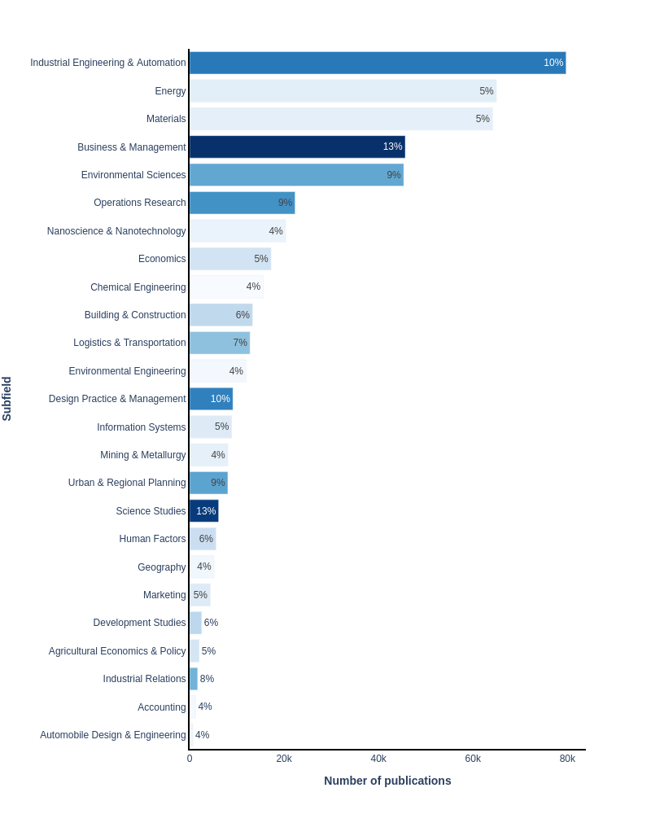

Figure 1. Top 25 subfields with the largest percentage of Scopus publication included in the publication set.

## Journals

In this section, we show how the publication set, captured by the query above, relates to scholarly journals. Journals are sorted in terms of their relevance using term frequency-inverse document frequency (TF-IDF). The horizontal bars are proportional to the number of publications contributed by the journal to the current publication set. The number alongside the horizontal bar is the proportion of the journal contributing to this publication set.

The articles on this topic are published most frequently in the following journals: *Proceedings of SPIE - The International Society for Optical Engineering* (14,770 publications), *Journal of Cleaner Production* (11,511), and *Sustainability (Switzerland)* (8,382).

Note, larger journals may not appear in the table below, as their SDG contribution may be relatively small compared to the size of the journal.

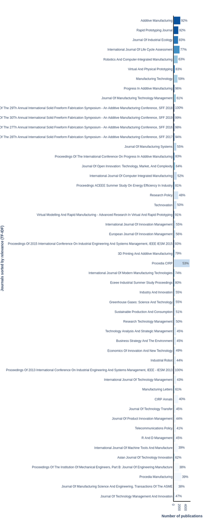

Figure 2. Top 50 journals, in terms of relevance (TF-IDF), for this publication set.

## Keywords

Elsevier’s [Scopus](https://www.scopus.com/search/form.uri?display=basic#basic) database of scientific literature, was used for the table below. The document types included in the data sets are journal articles, reviews, short surveys and conference papers, covering the period 1996–2022. We refer to these documents collectively as “publications” or “papers”.

In order to help better illustrate the content of this set of publications, indicators associated with the keywords most specific to this set (according to a TF-IDF score) are presented below.

|  | Term | # of papers with this term in the publication set | # of papers with this term in all of Scopus | Relevance (TF-IDF) | Percentage of Scopus |
| --- | --- | --- | --- | --- | --- |
| 1 | micromachining process | 2064 | 2273 | 18.732 | 91 |
| 2 | closed-loop supply chain | 2008 | 2245 | 18.7033 | 89 |
| 3 | bulk micromachining | 1479 | 1639 | 18.6958 | 90 |
| 4 | micro-fabrication | 1738 | 1950 | 18.6901 | 89 |
| 5 | broadband wireless access | 1572 | 1769 | 18.6755 | 89 |
| 6 | laser micromachining | 2494 | 2832 | 18.6689 | 88 |
| 7 | micro-machining | 2372 | 2711 | 18.6594 | 87 |
| 8 | surface micromachining | 2383 | 2732 | 18.6533 | 87 |
| 9 | slm process | 1357 | 1549 | 18.6296 | 88 |
| 10 | microfabrication process | 1369 | 1567 | 18.626 | 87 |

[output cut: 990 more lines]